# AutoML with Feature Engineering: A Lending Club Analysis

In this tutorial, we will go through a step-by-step workflow to build models using H2O's AutoML to determine loan deliquency. The data for this exercise come from the public Lending Club data set, a description can be found [here](https://www.kaggle.com/pragyanbo/a-hitchhiker-s-guide-to-lending-club-loan-data/notebook).

We will highlight feature engineering methods to improve model performance.

## Workflow

1. Start the H2O-3 cluster
2. Import data
3. Train default models using H2O's AutoML
4. Feature engineering to improve model performance
5. Train models using transformed data with AutoML
6. (Optional) Assignment: Transform test data
7. Stop H2O-3 cluster

# Step 1 (of 7). Start the Sparkling Water cluster

We will begin by starting the Sparkling Water cluster and importing the data into our H2O cluster.

```python
#Initiate H2OContext on top of Spark
from pysparkling import *
hc = H2OContext.getOrCreate()

import h2o
```

```
Connecting to H2O server at http://e186a4c45c98:54323/h2o ... successful.
```

| H2O_cluster_uptime: | 08 secs |
| --- | --- |
| H2O_cluster_timezone: | Etc/UTC |
| H2O_data_parsing_timezone: | UTC |
| H2O_cluster_version: | 3.32.0.1 |
| H2O_cluster_version_age: | 13 days |
| H2O_cluster_name: | sparkling-water-h2o_local-1603306575796 |
| H2O_cluster_total_nodes: | 1 |
| H2O_cluster_free_memory: | 7.016 Gb |
| H2O_cluster_total_cores: | 16 |
| H2O_cluster_allowed_cores: | 16 |
| H2O_cluster_status: | locked, healthy |
| H2O_connection_url: | http://e186a4c45c98:54323/h2o |
| H2O_connection_proxy: | null |
| H2O_internal_security: | False |
| H2O_API_Extensions: | XGBoost, Algos, Amazon S3, Sparkling Water REST API Extensions, AutoML, Core V3, TargetEncoder, Core V4 |
| Python_version: | 3.6.11 final |

```
Sparkling Water Context:
 * Sparkling Water Version: 3.32.0.1-2-3.0
 * H2O name: sparkling-water-h2o_local-1603306575796
 * cluster size: 1
 * list of used nodes:
  (executorId, host, port)
  ------------------------
  (0,172.17.0.2,54321)
  ------------------------

  Open H2O Flow in browser: http://e186a4c45c98:54323/h2o (CMD + click in Mac OSX)
```

Note: The method you use for starting and stopping an Sparkling Water cluster will depend on how H2O is installed and configured on your system. Regardless of how H2O is installed, if you start a cluster, you will need to ensure that it is shut down when you are done.

# Step 2 (of 7). Import Data

This exploration of H2O will use a version of the Lending Club Loan Data that can be found on [Kaggle](https://www.kaggle.com/wendykan/lending-club-loan-data). This data consists of 15 variables:

| Id | Column Name | Description |
| --- | --- | --- |
| 1 | loan_amnt | Requested loan amount (US dollars) |
| 2 | term | Loan term length (months) |
| 3 | int_rate | Recommended interest rate |
| 4 | emp_length | Employment length (years) |
| 5 | home_ownership | Housing status |
| 6 | annual_inc | Annual income (US dollars) |
| 7 | purpose | Purpose for the loan |
| 8 | addr_state | State of residence |
| 9 | dti | Debt to income ratio |
| 10 | delinq_2yrs | Number of delinquencies in the past 2 years |
| 11 | revol_util | Percent of revolving credit line utilized |
| 12 | total_acc | Number of active accounts |
| 13 | bad_loan | Bad loan indicator |
| 14 | longest_credit_length | Age of oldest active account |
| 15 | verification_status | Income verification status |

```python
import os
input_csv = "/home/h2o/data/automl/loan.csv"

if not os.path.exists(input_csv):
    input_csv = input_csv = "https://s3-us-west-2.amazonaws.com/h2o-tutorials/data/topics/data/automl/loan.csv"

loans = h2o.import_file(input_csv)
loans["bad_loan"] = loans["bad_loan"].asfactor()

loans.describe()
```

```
Parse progress: |█████████████████████████████████████████████████████████| 100%
Rows:163987
Cols:15
```

|  | loan_amnt | term | int_rate | emp_length | home_ownership | annual_inc | purpose | addr_state | dti | delinq_2yrs | revol_util | total_acc | bad_loan | longest_credit_length | verification_status |
| --- | --- | --- | --- | --- | --- | --- | --- | --- | --- | --- | --- | --- | --- | --- | --- |
| type | int | enum | real | int | enum | real | enum | enum | real | int | real | int | enum | int | enum |
| mins | 500.0 |  | 5.42 | 0.0 |  | 1896.0 |  |  | 0.0 | 0.0 | 0.0 | 1.0 |  | 0.0 |  |
| mean | 13074.169141456337 |  | 13.715904065566173 | 5.684352932995329 |  | 71915.670519749 |  |  | 15.881530121290105 | 0.2273570060625282 | 54.07917280242256 | 24.579733834274627 |  | 14.854273655448347 |  |
| maxs | 35000.0 |  | 26.06 | 10.0 |  | 7141778.0 |  |  | 39.99 | 29.0 | 150.70000000000002 | 118.0 |  | 65.0 |  |
| sigma | 7993.55618873465 |  | 4.3919398705457935 | 3.610663731100236 |  | 59070.91565491825 |  |  | 7.587668224192548 | 0.6941679229284182 | 25.285366766770505 | 11.685190365910659 |  | 6.947732922546696 |  |
| zeros | 0 |  | 0 | 14248 |  | 0 |  |  | 270 | 139459 | 1562 | 0 |  | 11 |  |
| missing | 0 | 0 | 0 | 5804 | 0 | 4 | 0 | 0 | 0 | 29 | 193 | 29 | 0 | 29 | 0 |
| 0 | 5000.0 | 36 months | 10.65 | 10.0 | RENT | 24000.0 | credit_card | AZ | 27.65 | 0.0 | 83.7 | 9.0 | 0 | 26.0 | verified |
| 1 | 2500.0 | 60 months | 15.27 | 0.0 | RENT | 30000.0 | car | GA | 1.0 | 0.0 | 9.4 | 4.0 | 1 | 12.0 | verified |
| 2 | 2400.0 | 36 months | 15.96 | 10.0 | RENT | 12252.0 | small_business | IL | 8.72 | 0.0 | 98.5 | 10.0 | 0 | 10.0 | not verified |
| 3 | 10000.0 | 36 months | 13.49 | 10.0 | RENT | 49200.0 | other | CA | 20.0 | 0.0 | 21.0 | 37.0 | 0 | 15.0 | verified |
| 4 | 5000.0 | 36 months | 7.9 | 3.0 | RENT | 36000.0 | wedding | AZ | 11.2 | 0.0 | 28.3 | 12.0 | 0 | 7.0 | verified |
| 5 | 3000.0 | 36 months | 18.64 | 9.0 | RENT | 48000.0 | car | CA | 5.3500000000000005 | 0.0 | 87.5 | 4.0 | 0 | 4.0 | verified |
| 6 | 5600.0 | 60 months | 21.28 | 4.0 | OWN | 40000.0 | small_business | CA | 5.55 | 0.0 | 32.6 | 13.0 | 1 | 7.0 | verified |
| 7 | 5375.0 | 60 months | 12.69 | 0.0 | RENT | 15000.0 | other | TX | 18.08 | 0.0 | 36.5 | 3.0 | 1 | 7.0 | verified |
| 8 | 6500.0 | 60 months | 14.65 | 5.0 | OWN | 72000.0 | debt_consolidation | AZ | 16.12 | 0.0 | 20.6 | 23.0 | 0 | 13.0 | not verified |
| 9 | 12000.0 | 36 months | 12.69 | 10.0 | OWN | 75000.0 | debt_consolidation | CA | 10.78 | 0.0 | 67.10000000000001 | 34.0 | 0 | 22.0 | verified |

# Step 3 (of 7). Train Default Models with AutoML

Start by splitting the data into train and test sets

```python
train, test = loans.split_frame(seed=1234, ratios=[0.8])
```

```python
# Set target and predictor variables
response = "bad_loan"
predictors = train.col_names
predictors.remove(response)
predictors.remove("int_rate")

# Use Auto ML to train models
from h2o.automl import H2OAutoML
aml = H2OAutoML(max_models = 6, exclude_algos = ['GLM', 'DeepLearning'])
aml.train(x = predictors, y = response, training_frame = train)
```

```
AutoML progress: |████████████████████████████████████████████████████████| 100%
```

Print out a leaderboard with the 6 best models and two ensembles: a stacked ensemble of all models, and a best-of-family stacked ensemble:

```python
print(aml.leaderboard)
```

| model_id | auc | logloss | aucpr | mean_per_class_error | rmse | mse |
| --- | --- | --- | --- | --- | --- | --- |
| StackedEnsemble_AllModels_AutoML_20201021_190124 | 0.685531 | 0.444741 | 0.324586 | 0.366541 | 0.373894 | 0.139797 |
| StackedEnsemble_BestOfFamily_AutoML_20201021_190124 | 0.685157 | 0.444842 | 0.324238 | 0.365403 | 0.373933 | 0.139826 |
| GBM_1_AutoML_20201021_190124 | 0.682564 | 0.44393 | 0.320273 | 0.369338 | 0.373707 | 0.139657 |
| XGBoost_3_AutoML_20201021_190124 | 0.680525 | 0.444465 | 0.31909 | 0.36987 | 0.373977 | 0.139859 |
| GBM_2_AutoML_20201021_190124 | 0.680332 | 0.444712 | 0.318456 | 0.369643 | 0.374058 | 0.13992 |
| DRF_1_AutoML_20201021_190124 | 0.662887 | 0.452643 | 0.301857 | 0.380906 | 0.377045 | 0.142163 |
| XGBoost_1_AutoML_20201021_190124 | 0.659978 | 0.457034 | 0.291246 | 0.382977 | 0.379543 | 0.144053 |
| XGBoost_2_AutoML_20201021_190124 | 0.643047 | 0.471514 | 0.280648 | 0.396632 | 0.384823 | 0.148089 |

As is frequently the case, the stacked ensemble models are among the best performers.

## Examine the Top Model

The `aml.leader` object contains the top model from the leaderboard

```python
top_model = aml.leader
```

Details for both training and cross-validated data are contained in `aml.leader`

```python
aml.leader
```

```
Model Details
=============
H2OStackedEnsembleEstimator :  Stacked Ensemble
Model Key:  StackedEnsemble_AllModels_AutoML_20201021_190124

No model summary for this model

ModelMetricsBinomialGLM: stackedensemble
** Reported on train data. **

MSE: 0.1147125470913994
RMSE: 0.3386924077852933
LogLoss: 0.374520115378425
Null degrees of freedom: 9949
Residual degrees of freedom: 9943
Null deviance: 9369.279727528428
Residual deviance: 7452.950296030658
AIC: 7466.950296030658
AUC: 0.8595920308932145
AUCPR: 0.5954407126616156
Gini: 0.7191840617864289

Confusion Matrix (Act/Pred) for max f1 @ threshold = 0.21521321334717783:
```

|  |  | 0 | 1 | Error | Rate |
| --- | --- | --- | --- | --- | --- |
| 0 | 0 | 6905.0 | 1258.0 | 0.1541 | (1258.0/8163.0) |
| 1 | 1 | 576.0 | 1211.0 | 0.3223 | (576.0/1787.0) |
| 2 | Total | 7481.0 | 2469.0 | 0.1843 | (1834.0/9950.0) |

```
Maximum Metrics: Maximum metrics at their respective thresholds
```

|  | metric | threshold | value | idx |
| --- | --- | --- | --- | --- |
| 0 | max f1 | 0.215213 | 0.569079 | 227.0 |
| 1 | max f2 | 0.159669 | 0.682273 | 284.0 |
| 2 | max f0point5 | 0.312869 | 0.580453 | 155.0 |
| 3 | max accuracy | 0.312869 | 0.854472 | 155.0 |
| 4 | max precision | 0.857193 | 1.000000 | 0.0 |
| 5 | max recall | 0.097173 | 1.000000 | 370.0 |
| 6 | max specificity | 0.857193 | 1.000000 | 0.0 |
| 7 | max absolute_mcc | 0.215213 | 0.465281 | 227.0 |
| 8 | max min_per_class_accuracy | 0.186611 | 0.772244 | 253.0 |
| 9 | max mean_per_class_accuracy | 0.178998 | 0.774711 | 261.0 |
| 10 | max tns | 0.857193 | 8163.000000 | 0.0 |
| 11 | max fns | 0.857193 | 1786.000000 | 0.0 |
| 12 | max fps | 0.071812 | 8163.000000 | 399.0 |
| 13 | max tps | 0.097173 | 1787.000000 | 370.0 |
| 14 | max tnr | 0.857193 | 1.000000 | 0.0 |
| 15 | max fnr | 0.857193 | 0.999440 | 0.0 |
| 16 | max fpr | 0.071812 | 1.000000 | 399.0 |
| 17 | max tpr | 0.097173 | 1.000000 | 370.0 |

```
Gains/Lift Table: Avg response rate: 17.96 %, avg score: 18.29 %
```

|  | group | cumulative_data_fraction | lower_threshold | lift | cumulative_lift | response_rate | score | cumulative_response_rate | cumulative_score | capture_rate | cumulative_capture_rate | gain | cumulative_gain | kolmogorov_smirnov |
| --- | --- | --- | --- | --- | --- | --- | --- | --- | --- | --- | --- | --- | --- | --- |
| 0 | 1 | 0.01005 | 0.583310 | 5.066872 | 5.066872 | 0.910000 | 0.672114 | 0.910000 | 0.672114 | 0.050923 | 0.050923 | 406.687185 | 406.687185 | 0.049821 |
| 1 | 2 | 0.02000 | 0.529350 | 4.611871 | 4.840515 | 0.828283 | 0.555453 | 0.869347 | 0.614076 | 0.045887 | 0.096810 | 361.187137 | 384.051483 | 0.093625 |
| 2 | 3 | 0.03005 | 0.484234 | 4.287353 | 4.655511 | 0.770000 | 0.507019 | 0.836120 | 0.578271 | 0.043089 | 0.139899 | 328.735311 | 365.551091 | 0.133897 |
| 3 | 4 | 0.04000 | 0.444845 | 4.105690 | 4.518747 | 0.737374 | 0.464332 | 0.811558 | 0.549930 | 0.040851 | 0.180750 | 310.569037 | 351.874650 | 0.171562 |
| 4 | 5 | 0.05005 | 0.419028 | 3.396475 | 4.293391 | 0.610000 | 0.431307 | 0.771084 | 0.526110 | 0.034135 | 0.214885 | 239.647454 | 329.339069 | 0.200920 |
| 5 | 6 | 0.10000 | 0.319182 | 3.080880 | 3.687745 | 0.553320 | 0.364703 | 0.662312 | 0.445487 | 0.153889 | 0.368774 | 208.088036 | 268.774482 | 0.327613 |
| 6 | 7 | 0.15005 | 0.269441 | 2.359129 | 3.244576 | 0.423695 | 0.293410 | 0.582719 | 0.394761 | 0.118075 | 0.486849 | 135.912874 | 224.457616 | 0.410529 |
| 7 | 8 | 0.20000 | 0.235950 | 1.949357 | 2.921097 | 0.350101 | 0.251859 | 0.524623 | 0.359071 | 0.097370 | 0.584219 | 94.935703 | 192.109681 | 0.468331 |
| 8 | 9 | 0.30000 | 0.193793 | 1.600448 | 2.480880 | 0.287437 | 0.213694 | 0.445561 | 0.310612 | 0.160045 | 0.744264 | 60.044768 | 148.088043 | 0.541520 |
| 9 | 10 | 0.40000 | 0.166947 | 0.996083 | 2.109681 | 0.178894 | 0.179187 | 0.378894 | 0.277756 | 0.099608 | 0.843872 | -0.391718 | 110.968103 | 0.541043 |
| 10 | 11 | 0.50000 | 0.146537 | 0.721880 | 1.832121 | 0.129648 | 0.156390 | 0.329045 | 0.253483 | 0.072188 | 0.916060 | -27.811975 | 83.212087 | 0.507142 |
| 11 | 12 | 0.60000 | 0.131166 | 0.470062 | 1.605111 | 0.084422 | 0.138578 | 0.288275 | 0.234332 | 0.047006 | 0.963067 | -52.993844 | 60.511099 | 0.442547 |
| 12 | 13 | 0.70000 | 0.117957 | 0.207051 | 1.405388 | 0.037186 | 0.124514 | 0.252405 | 0.218644 | 0.020705 | 0.983772 | -79.294908 | 40.538812 | 0.345893 |
| 13 | 14 | 0.80000 | 0.106094 | 0.134303 | 1.246503 | 0.024121 | 0.111942 | 0.223869 | 0.205306 | 0.013430 | 0.997202 | -86.569670 | 24.650252 | 0.240372 |
| 14 | 15 | 0.90000 | 0.094460 | 0.027980 | 1.111111 | 0.005025 | 0.100171 | 0.199553 | 0.193624 | 0.002798 | 1.000000 | -97.202015 | 11.111111 | 0.121891 |
| 15 | 16 | 1.00000 | 0.070430 | 0.000000 | 1.000000 | 0.000000 | 0.086565 | 0.179598 | 0.182918 | 0.000000 | 1.000000 | -100.000000 | 0.000000 | 0.000000 |

```
ModelMetricsBinomialGLM: stackedensemble
** Reported on cross-validation data. **

MSE: 0.1397968719148754
RMSE: 0.37389419882484853
LogLoss: 0.4447410117844631
Null degrees of freedom: 131309
Residual degrees of freedom: 131303
Null deviance: 124910.41274308879
Residual deviance: 116797.8845148357
AIC: 116811.8845148357
AUC: 0.6855312601310354
AUCPR: 0.3245856705920853
Gini: 0.37106252026207076

Confusion Matrix (Act/Pred) for max f1 @ threshold = 0.18078109167889908:
```

|  |  | 0 | 1 | Error | Rate |
| --- | --- | --- | --- | --- | --- |
| 0 | 0 | 74514.0 | 32791.0 | 0.3056 | (32791.0/107305.0) |
| 1 | 1 | 10262.0 | 13743.0 | 0.4275 | (10262.0/24005.0) |
| 2 | Total | 84776.0 | 46534.0 | 0.3279 | (43053.0/131310.0) |

```
Maximum Metrics: Maximum metrics at their respective thresholds
```

|  | metric | threshold | value | idx |
| --- | --- | --- | --- | --- |
| 0 | max f1 | 0.180781 | 0.389657 | 271.0 |
| 1 | max f2 | 0.117369 | 0.554177 | 348.0 |
| 2 | max f0point5 | 0.271581 | 0.351708 | 190.0 |
| 3 | max accuracy | 0.607333 | 0.817539 | 34.0 |
| 4 | max precision | 0.812017 | 0.833333 | 4.0 |
| 5 | max recall | 0.072213 | 1.000000 | 399.0 |
| 6 | max specificity | 0.863524 | 0.999981 | 0.0 |
| 7 | max absolute_mcc | 0.190988 | 0.216505 | 260.0 |
| 8 | max min_per_class_accuracy | 0.166361 | 0.632410 | 287.0 |
| 9 | max mean_per_class_accuracy | 0.173626 | 0.634508 | 279.0 |
| 10 | max tns | 0.863524 | 107303.000000 | 0.0 |
| 11 | max fns | 0.863524 | 24002.000000 | 0.0 |
| 12 | max fps | 0.072213 | 107305.000000 | 399.0 |
| 13 | max tps | 0.072213 | 24005.000000 | 399.0 |
| 14 | max tnr | 0.863524 | 0.999981 | 0.0 |
| 15 | max fnr | 0.863524 | 0.999875 | 0.0 |
| 16 | max fpr | 0.072213 | 1.000000 | 399.0 |
| 17 | max tpr | 0.072213 | 1.000000 | 399.0 |

```
Gains/Lift Table: Avg response rate: 18.28 %, avg score: 18.28 %
```

|  | group | cumulative_data_fraction | lower_threshold | lift | cumulative_lift | response_rate | score | cumulative_response_rate | cumulative_score | capture_rate | cumulative_capture_rate | gain | cumulative_gain | kolmogorov_smirnov |
| --- | --- | --- | --- | --- | --- | --- | --- | --- | --- | --- | --- | --- | --- | --- |
| 0 | 1 | 0.010007 | 0.564049 | 2.785011 | 2.785011 | 0.509132 | 0.631264 | 0.509132 | 0.631264 | 0.027869 | 0.027869 | 178.501054 | 178.501054 | 0.021858 |
| 1 | 2 | 0.020006 | 0.500365 | 2.441344 | 2.613243 | 0.446306 | 0.528696 | 0.477731 | 0.579999 | 0.024412 | 0.052281 | 144.134401 | 161.324269 | 0.039495 |
| 2 | 3 | 0.030005 | 0.459765 | 2.383018 | 2.536521 | 0.435644 | 0.479693 | 0.463706 | 0.546572 | 0.023828 | 0.076109 | 138.301839 | 153.652073 | 0.056418 |
| 3 | 4 | 0.040005 | 0.427425 | 2.237204 | 2.461706 | 0.408987 | 0.443361 | 0.450029 | 0.520775 | 0.022370 | 0.098479 | 123.720433 | 146.170588 | 0.071556 |
| 4 | 5 | 0.050004 | 0.402836 | 2.316361 | 2.432641 | 0.423458 | 0.414628 | 0.444715 | 0.499549 | 0.023162 | 0.121641 | 131.636053 | 143.264124 | 0.087663 |
| 5 | 6 | 0.100000 | 0.318471 | 1.918913 | 2.175797 | 0.350800 | 0.356544 | 0.397761 | 0.428052 | 0.095938 | 0.217580 | 91.891306 | 117.579671 | 0.143883 |
| 6 | 7 | 0.150004 | 0.270582 | 1.674524 | 2.008697 | 0.306122 | 0.292681 | 0.367213 | 0.382926 | 0.083733 | 0.301312 | 67.452359 | 100.869719 | 0.185157 |
| 7 | 8 | 0.200000 | 0.238010 | 1.468139 | 1.873568 | 0.268393 | 0.253462 | 0.342510 | 0.350562 | 0.073401 | 0.374714 | 46.813930 | 87.356801 | 0.213798 |
| 8 | 9 | 0.300000 | 0.196349 | 1.344720 | 1.697285 | 0.245830 | 0.215563 | 0.310284 | 0.305562 | 0.134472 | 0.509186 | 34.471985 | 69.728529 | 0.255982 |
| 9 | 10 | 0.400000 | 0.168873 | 1.103104 | 1.548740 | 0.201660 | 0.181833 | 0.283128 | 0.274630 | 0.110310 | 0.619496 | 10.310352 | 54.873985 | 0.268599 |
| 10 | 11 | 0.500000 | 0.148484 | 0.941471 | 1.427286 | 0.172112 | 0.158215 | 0.260925 | 0.251347 | 0.094147 | 0.713643 | -5.852947 | 42.728598 | 0.261437 |
| 11 | 12 | 0.600000 | 0.133043 | 0.826494 | 1.327154 | 0.151093 | 0.140445 | 0.242619 | 0.232863 | 0.082649 | 0.796292 | -17.350552 | 32.715407 | 0.240205 |
| 12 | 13 | 0.700000 | 0.119925 | 0.708602 | 1.238790 | 0.129541 | 0.126299 | 0.226465 | 0.217640 | 0.070860 | 0.867153 | -29.139763 | 23.878954 | 0.204546 |
| 13 | 14 | 0.800000 | 0.108282 | 0.573630 | 1.155645 | 0.104866 | 0.114042 | 0.211265 | 0.204690 | 0.057363 | 0.924516 | -42.636951 | 15.564466 | 0.152371 |
| 14 | 15 | 0.900000 | 0.096401 | 0.461154 | 1.078479 | 0.084304 | 0.102494 | 0.197159 | 0.193335 | 0.046115 | 0.970631 | -53.884607 | 7.847902 | 0.086432 |
| 15 | 16 | 1.000000 | 0.069507 | 0.293689 | 1.000000 | 0.053690 | 0.088090 | 0.182812 | 0.182811 | 0.029369 | 1.000000 | -70.631119 | 0.000000 | 0.000000 |

To get details for the holdout test data, use `model_performance` as shown below

```python
perf = aml.leader.model_performance(test_data=test)
perf
```

```
ModelMetricsBinomialGLM: stackedensemble
** Reported on test data. **

MSE: 0.14040618874473543
RMSE: 0.3747081380818082
LogLoss: 0.4464935905172828
Null degrees of freedom: 32676
Residual degrees of freedom: 32670
Null deviance: 31195.93792715086
Residual deviance: 29180.1421146665
AIC: 29194.1421146665
AUC: 0.6830426562527314
AUCPR: 0.32840397087989964
Gini: 0.36608531250546283

Confusion Matrix (Act/Pred) for max f1 @ threshold = 0.17793931333960922:
```

|  |  | 0 | 1 | Error | Rate |
| --- | --- | --- | --- | --- | --- |
| 0 | 0 | 18188.0 | 8478.0 | 0.3179 | (8478.0/26666.0) |
| 1 | 1 | 2528.0 | 3483.0 | 0.4206 | (2528.0/6011.0) |
| 2 | Total | 20716.0 | 11961.0 | 0.3368 | (11006.0/32677.0) |

```
Maximum Metrics: Maximum metrics at their respective thresholds
```

|  | metric | threshold | value | idx |
| --- | --- | --- | --- | --- |
| 0 | max f1 | 0.177939 | 0.387603 | 265.0 |
| 1 | max f2 | 0.116206 | 0.555971 | 345.0 |
| 2 | max f0point5 | 0.248772 | 0.352053 | 201.0 |
| 3 | max accuracy | 0.536091 | 0.817578 | 51.0 |
| 4 | max precision | 0.870812 | 1.000000 | 0.0 |
| 5 | max recall | 0.074720 | 1.000000 | 398.0 |
| 6 | max specificity | 0.870812 | 1.000000 | 0.0 |
| 7 | max absolute_mcc | 0.206185 | 0.211228 | 237.0 |
| 8 | max min_per_class_accuracy | 0.165683 | 0.629453 | 279.0 |
| 9 | max mean_per_class_accuracy | 0.153370 | 0.631915 | 293.0 |
| 10 | max tns | 0.870812 | 26666.000000 | 0.0 |
| 11 | max fns | 0.870812 | 6010.000000 | 0.0 |
| 12 | max fps | 0.072713 | 26666.000000 | 399.0 |
| 13 | max tps | 0.074720 | 6011.000000 | 398.0 |
| 14 | max tnr | 0.870812 | 1.000000 | 0.0 |
| 15 | max fnr | 0.870812 | 0.999834 | 0.0 |
| 16 | max fpr | 0.072713 | 1.000000 | 399.0 |
| 17 | max tpr | 0.074720 | 1.000000 | 398.0 |

```
Gains/Lift Table: Avg response rate: 18.40 %, avg score: 18.26 %
```

|  | group | cumulative_data_fraction | lower_threshold | lift | cumulative_lift | response_rate | score | cumulative_response_rate | cumulative_score | capture_rate | cumulative_capture_rate | gain | cumulative_gain | kolmogorov_smirnov |
| --- | --- | --- | --- | --- | --- | --- | --- | --- | --- | --- | --- | --- | --- | --- |
| 0 | 1 | 0.010007 | 0.561619 | 3.009028 | 3.009028 | 0.553517 | 0.626652 | 0.553517 | 0.626652 | 0.030111 | 0.030111 | 200.902830 | 200.902830 | 0.024636 |
| 1 | 2 | 0.020014 | 0.501491 | 2.543543 | 2.776286 | 0.467890 | 0.528480 | 0.510703 | 0.577566 | 0.025453 | 0.055565 | 154.354326 | 177.628578 | 0.043564 |
| 2 | 3 | 0.030021 | 0.459502 | 2.294176 | 2.615583 | 0.422018 | 0.477672 | 0.481142 | 0.544268 | 0.022958 | 0.078523 | 129.417627 | 161.558261 | 0.059435 |
| 3 | 4 | 0.040028 | 0.425892 | 2.211054 | 2.514450 | 0.406728 | 0.442620 | 0.462538 | 0.518856 | 0.022126 | 0.100649 | 121.105394 | 151.445044 | 0.074286 |
| 4 | 5 | 0.050005 | 0.399400 | 2.067757 | 2.425330 | 0.380368 | 0.412163 | 0.446144 | 0.497570 | 0.020629 | 0.121278 | 106.775717 | 142.533049 | 0.087339 |
| 5 | 6 | 0.100009 | 0.316600 | 1.939599 | 2.182465 | 0.356793 | 0.352940 | 0.401469 | 0.425255 | 0.096989 | 0.218267 | 93.959901 | 118.246475 | 0.144915 |
| 6 | 7 | 0.150014 | 0.268267 | 1.616887 | 1.993939 | 0.297430 | 0.290893 | 0.366789 | 0.380467 | 0.080852 | 0.299118 | 61.688699 | 99.393883 | 0.182715 |
| 7 | 8 | 0.200018 | 0.237685 | 1.513752 | 1.873892 | 0.278458 | 0.251982 | 0.344706 | 0.348346 | 0.075695 | 0.374813 | 51.375223 | 87.389218 | 0.214196 |
| 8 | 9 | 0.299997 | 0.196234 | 1.284587 | 1.677497 | 0.236302 | 0.215264 | 0.308579 | 0.303994 | 0.128431 | 0.503244 | 28.458728 | 67.749729 | 0.249063 |
| 9 | 10 | 0.400006 | 0.169191 | 1.079588 | 1.528009 | 0.198592 | 0.181970 | 0.281080 | 0.273486 | 0.107969 | 0.611213 | 7.958813 | 52.800856 | 0.258816 |
| 10 | 11 | 0.500015 | 0.149197 | 1.004732 | 1.423347 | 0.184823 | 0.158808 | 0.261828 | 0.250549 | 0.100482 | 0.711695 | 0.473225 | 42.334689 | 0.259396 |
| 11 | 12 | 0.599994 | 0.133541 | 0.807027 | 1.320648 | 0.148454 | 0.141001 | 0.242936 | 0.232295 | 0.080685 | 0.792381 | -19.297302 | 32.064786 | 0.235754 |
| 12 | 13 | 0.700003 | 0.120500 | 0.751886 | 1.239389 | 0.138311 | 0.126926 | 0.227988 | 0.217241 | 0.075195 | 0.867576 | -24.811428 | 23.938903 | 0.205347 |
| 13 | 14 | 0.799982 | 0.108612 | 0.577399 | 1.156656 | 0.106214 | 0.114521 | 0.212769 | 0.204403 | 0.057727 | 0.925304 | -42.260131 | 15.665606 | 0.153572 |
| 14 | 15 | 0.899991 | 0.096273 | 0.460780 | 1.079329 | 0.084761 | 0.102506 | 0.198545 | 0.193080 | 0.046082 | 0.971386 | -53.922048 | 7.932856 | 0.087489 |
| 15 | 16 | 1.000000 | 0.069966 | 0.286116 | 1.000000 | 0.052632 | 0.087889 | 0.183952 | 0.182560 | 0.028614 | 1.000000 | -71.388419 | 0.000000 | 0.000000 |

We can look at overall performance of the top model by

```python
print("AUC:     train = {:.4f}, xval = {:.4f}, test = {:.4f}" \
      .format(aml.leader.auc(train = True), aml.leader.auc(xval = True), perf.auc()))
print("Logloss: train = {:.4f}, xval = {:.4f}, test = {:.4f}" \
      .format(aml.leader.logloss(train = True), aml.leader.logloss(xval = True), perf.logloss()))
```

```
AUC:     train = 0.8596, xval = 0.6855, test = 0.6830
Logloss: train = 0.3745, xval = 0.4447, test = 0.4465
```

Note that the cross-validation and test data metrics are very similar, but there is a gap between training and test metrics. Those for training are overly optimistic.

## Examine a Selected Model

In practice, the top performing model ranked by a leaderboard may not necessarily be the model you want to put into production. Other considerations, such as modeling type, regulatory or internal business preferences, likelihood of model approval, etc., may play a role in determining which model to use.

Here we demonstrate how to select and evaluate any model from the leaderboard.

```python
aml.leaderboard
```

| model_id | auc | logloss | aucpr | mean_per_class_error | rmse | mse |
| --- | --- | --- | --- | --- | --- | --- |
| StackedEnsemble_AllModels_AutoML_20201021_190124 | 0.685531 | 0.444741 | 0.324586 | 0.366541 | 0.373894 | 0.139797 |
| StackedEnsemble_BestOfFamily_AutoML_20201021_190124 | 0.685157 | 0.444842 | 0.324238 | 0.365403 | 0.373933 | 0.139826 |
| GBM_1_AutoML_20201021_190124 | 0.682564 | 0.44393 | 0.320273 | 0.369338 | 0.373707 | 0.139657 |
| XGBoost_3_AutoML_20201021_190124 | 0.680525 | 0.444465 | 0.31909 | 0.36987 | 0.373977 | 0.139859 |
| GBM_2_AutoML_20201021_190124 | 0.680332 | 0.444712 | 0.318456 | 0.369643 | 0.374058 | 0.13992 |
| DRF_1_AutoML_20201021_190124 | 0.662887 | 0.452643 | 0.301857 | 0.380906 | 0.377045 | 0.142163 |
| XGBoost_1_AutoML_20201021_190124 | 0.659978 | 0.457034 | 0.291246 | 0.382977 | 0.379543 | 0.144053 |
| XGBoost_2_AutoML_20201021_190124 | 0.643047 | 0.471514 | 0.280648 | 0.396632 | 0.384823 | 0.148089 |

We can select an specified model from the leaderboard by indicating its position. The following code will select the best model that is not a stacked ensemble:

```python
m = aml.leaderboard['model_id'].grep("StackedEnsemble", invert=True).min()
select_model = h2o.get_model(aml.leaderboard[int(m),'model_id'])
```

We can look at performance with the selected model just as we did with the top model

```python
select_model
```

```
Model Details
=============
H2OGradientBoostingEstimator :  Gradient Boosting Machine
Model Key:  GBM_1_AutoML_20201021_190124


Model Summary:
```

|  |  | number_of_trees | number_of_internal_trees | model_size_in_bytes | min_depth | max_depth | mean_depth | min_leaves | max_leaves | mean_leaves |
| --- | --- | --- | --- | --- | --- | --- | --- | --- | --- | --- |
| 0 |  | 52.0 | 52.0 | 48807.0 | 6.0 | 6.0 | 6.0 | 33.0 | 64.0 | 59.76923 |

```
ModelMetricsBinomial: gbm
** Reported on train data. **

MSE: 0.1330711710706798
RMSE: 0.36478921457559543
LogLoss: 0.4252663301049656
Mean Per-Class Error: 0.3361942024313641
AUC: 0.7284583614376581
AUCPR: 0.4028367518691584
Gini: 0.45691672287531615

Confusion Matrix (Act/Pred) for max f1 @ threshold = 0.2098345576668031:
```

|  |  | 0 | 1 | Error | Rate |
| --- | --- | --- | --- | --- | --- |
| 0 | 0 | 80586.0 | 26719.0 | 0.249 | (26719.0/107305.0) |
| 1 | 1 | 10247.0 | 13758.0 | 0.4269 | (10247.0/24005.0) |
| 2 | Total | 90833.0 | 40477.0 | 0.2815 | (36966.0/131310.0) |

```
Maximum Metrics: Maximum metrics at their respective thresholds
```

|  | metric | threshold | value | idx |
| --- | --- | --- | --- | --- |
| 0 | max f1 | 0.209835 | 0.426724 | 219.0 |
| 1 | max f2 | 0.130339 | 0.571710 | 304.0 |
| 2 | max f0point5 | 0.306872 | 0.420256 | 140.0 |
| 3 | max accuracy | 0.451210 | 0.824263 | 63.0 |
| 4 | max precision | 0.819189 | 1.000000 | 0.0 |
| 5 | max recall | 0.037435 | 1.000000 | 397.0 |
| 6 | max specificity | 0.819189 | 1.000000 | 0.0 |
| 7 | max absolute_mcc | 0.258818 | 0.276105 | 177.0 |
| 8 | max min_per_class_accuracy | 0.183481 | 0.663128 | 246.0 |
| 9 | max mean_per_class_accuracy | 0.195742 | 0.663806 | 233.0 |
| 10 | max tns | 0.819189 | 107305.000000 | 0.0 |
| 11 | max fns | 0.819189 | 24004.000000 | 0.0 |
| 12 | max fps | 0.031710 | 107305.000000 | 399.0 |
| 13 | max tps | 0.037435 | 24005.000000 | 397.0 |
| 14 | max tnr | 0.819189 | 1.000000 | 0.0 |
| 15 | max fnr | 0.819189 | 0.999958 | 0.0 |
| 16 | max fpr | 0.031710 | 1.000000 | 399.0 |
| 17 | max tpr | 0.037435 | 1.000000 | 397.0 |

```
Gains/Lift Table: Avg response rate: 18.28 %, avg score: 18.28 %
```

|  | group | cumulative_data_fraction | lower_threshold | lift | cumulative_lift | response_rate | score | cumulative_response_rate | cumulative_score | capture_rate | cumulative_capture_rate | gain | cumulative_gain | kolmogorov_smirnov |
| --- | --- | --- | --- | --- | --- | --- | --- | --- | --- | --- | --- | --- | --- | --- |
| 0 | 1 | 0.010007 | 0.504548 | 4.108827 | 4.108827 | 0.751142 | 0.561101 | 0.751142 | 0.561101 | 0.041116 | 0.041116 | 310.882721 | 310.882721 | 0.038069 |
| 1 | 2 | 0.020006 | 0.457167 | 3.266235 | 3.687691 | 0.597106 | 0.478710 | 0.674153 | 0.519922 | 0.032660 | 0.073776 | 226.623500 | 268.769148 | 0.065799 |
| 2 | 3 | 0.030005 | 0.428021 | 2.741304 | 3.372309 | 0.501142 | 0.441720 | 0.616497 | 0.493861 | 0.027411 | 0.101187 | 174.130437 | 237.230917 | 0.087106 |
| 3 | 4 | 0.040005 | 0.405246 | 2.666314 | 3.195844 | 0.487433 | 0.416208 | 0.584238 | 0.474451 | 0.026661 | 0.127848 | 166.631428 | 219.584405 | 0.107495 |
| 4 | 5 | 0.050004 | 0.386716 | 2.532999 | 3.063295 | 0.463062 | 0.395943 | 0.560006 | 0.458752 | 0.025328 | 0.153176 | 153.299857 | 206.329514 | 0.126253 |
| 5 | 6 | 0.100000 | 0.322166 | 2.252202 | 2.657780 | 0.411729 | 0.351214 | 0.485873 | 0.404987 | 0.112602 | 0.265778 | 125.220234 | 165.777963 | 0.202864 |
| 6 | 7 | 0.150004 | 0.281985 | 1.807819 | 2.374445 | 0.330490 | 0.300881 | 0.434076 | 0.370283 | 0.090398 | 0.356176 | 80.781900 | 137.444504 | 0.252294 |
| 7 | 8 | 0.200000 | 0.253103 | 1.539796 | 2.165799 | 0.281493 | 0.266855 | 0.395933 | 0.344428 | 0.076984 | 0.433160 | 53.979650 | 116.579879 | 0.285319 |
| 8 | 9 | 0.300000 | 0.211978 | 1.298896 | 1.876831 | 0.237453 | 0.231113 | 0.343107 | 0.306656 | 0.129890 | 0.563049 | 29.889606 | 87.683122 | 0.321896 |
| 9 | 10 | 0.400000 | 0.181969 | 1.038117 | 1.667153 | 0.189780 | 0.196240 | 0.304775 | 0.279052 | 0.103812 | 0.666861 | 3.811706 | 66.715268 | 0.326560 |
| 10 | 11 | 0.500000 | 0.157989 | 0.902312 | 1.514185 | 0.164953 | 0.169749 | 0.276811 | 0.257192 | 0.090231 | 0.757092 | -9.768798 | 51.418454 | 0.314606 |
| 11 | 12 | 0.600000 | 0.137735 | 0.745678 | 1.386100 | 0.136319 | 0.147645 | 0.253395 | 0.238934 | 0.074568 | 0.831660 | -25.432202 | 38.610012 | 0.283484 |
| 12 | 13 | 0.700000 | 0.118877 | 0.627369 | 1.277710 | 0.114690 | 0.128146 | 0.233580 | 0.223107 | 0.062737 | 0.894397 | -37.263070 | 27.771000 | 0.237885 |
| 13 | 14 | 0.800000 | 0.100913 | 0.501979 | 1.180744 | 0.091768 | 0.109927 | 0.215854 | 0.208960 | 0.050198 | 0.944595 | -49.802125 | 18.074360 | 0.176942 |
| 14 | 15 | 0.900000 | 0.080665 | 0.359508 | 1.089495 | 0.065722 | 0.091144 | 0.199172 | 0.195869 | 0.035951 | 0.980546 | -64.049156 | 8.949524 | 0.098564 |
| 15 | 16 | 1.000000 | 0.025179 | 0.194543 | 1.000000 | 0.035565 | 0.065340 | 0.182812 | 0.182816 | 0.019454 | 1.000000 | -80.545720 | 0.000000 | 0.000000 |

```
ModelMetricsBinomial: gbm
** Reported on cross-validation data. **

MSE: 0.13965678833945377
RMSE: 0.37370682137131744
LogLoss: 0.4439300540870672
Mean Per-Class Error: 0.3682144903237574
AUC: 0.6825637266423448
AUCPR: 0.32027299970411344
Gini: 0.36512745328468954

Confusion Matrix (Act/Pred) for max f1 @ threshold = 0.19865475308096783:
```

|  |  | 0 | 1 | Error | Rate |
| --- | --- | --- | --- | --- | --- |
| 0 | 0 | 75733.0 | 31572.0 | 0.2942 | (31572.0/107305.0) |
| 1 | 1 | 10669.0 | 13336.0 | 0.4444 | (10669.0/24005.0) |
| 2 | Total | 86402.0 | 44908.0 | 0.3217 | (42241.0/131310.0) |

```
Maximum Metrics: Maximum metrics at their respective thresholds
```

|  | metric | threshold | value | idx |
| --- | --- | --- | --- | --- |
| 0 | max f1 | 0.198655 | 0.387039 | 230.0 |
| 1 | max f2 | 0.110373 | 0.553338 | 327.0 |
| 2 | max f0point5 | 0.269460 | 0.349587 | 168.0 |
| 3 | max accuracy | 0.532815 | 0.817287 | 35.0 |
| 4 | max precision | 0.709143 | 0.645161 | 6.0 |
| 5 | max recall | 0.034362 | 1.000000 | 398.0 |
| 6 | max specificity | 0.826296 | 0.999991 | 0.0 |
| 7 | max absolute_mcc | 0.207537 | 0.213670 | 221.0 |
| 8 | max min_per_class_accuracy | 0.178061 | 0.631173 | 251.0 |
| 9 | max mean_per_class_accuracy | 0.174683 | 0.631786 | 254.0 |
| 10 | max tns | 0.826296 | 107304.000000 | 0.0 |
| 11 | max fns | 0.826296 | 24004.000000 | 0.0 |
| 12 | max fps | 0.029675 | 107305.000000 | 399.0 |
| 13 | max tps | 0.034362 | 24005.000000 | 398.0 |
| 14 | max tnr | 0.826296 | 0.999991 | 0.0 |
| 15 | max fnr | 0.826296 | 0.999958 | 0.0 |
| 16 | max fpr | 0.029675 | 1.000000 | 399.0 |
| 17 | max tpr | 0.034362 | 1.000000 | 398.0 |

```
Gains/Lift Table: Avg response rate: 18.28 %, avg score: 18.25 %
```

|  | group | cumulative_data_fraction | lower_threshold | lift | cumulative_lift | response_rate | score | cumulative_response_rate | cumulative_score | capture_rate | cumulative_capture_rate | gain | cumulative_gain | kolmogorov_smirnov |
| --- | --- | --- | --- | --- | --- | --- | --- | --- | --- | --- | --- | --- | --- | --- |
| 0 | 1 | 0.010007 | 0.501306 | 2.739218 | 2.739218 | 0.500761 | 0.557203 | 0.500761 | 0.557203 | 0.027411 | 0.027411 | 173.921814 | 173.921814 | 0.021298 |
| 1 | 2 | 0.020006 | 0.455725 | 2.449676 | 2.594502 | 0.447829 | 0.476198 | 0.474305 | 0.516716 | 0.024495 | 0.051906 | 144.967625 | 159.450230 | 0.039036 |
| 2 | 3 | 0.030005 | 0.426372 | 2.316361 | 2.501812 | 0.423458 | 0.439741 | 0.457360 | 0.491064 | 0.023162 | 0.075068 | 131.636053 | 150.181191 | 0.055143 |
| 3 | 4 | 0.040005 | 0.403047 | 2.312194 | 2.454417 | 0.422696 | 0.414320 | 0.448696 | 0.471882 | 0.023120 | 0.098188 | 131.219442 | 145.441656 | 0.071199 |
| 4 | 5 | 0.050004 | 0.385251 | 2.174713 | 2.398484 | 0.397563 | 0.393967 | 0.438471 | 0.456301 | 0.021745 | 0.119933 | 117.471259 | 139.848429 | 0.085573 |
| 5 | 6 | 0.100000 | 0.320812 | 1.912247 | 2.155384 | 0.349581 | 0.350157 | 0.394029 | 0.403233 | 0.095605 | 0.215538 | 91.224727 | 115.538429 | 0.141385 |
| 6 | 7 | 0.150004 | 0.281391 | 1.645365 | 1.985369 | 0.300792 | 0.299808 | 0.362949 | 0.368756 | 0.082275 | 0.297813 | 64.536522 | 98.536931 | 0.180875 |
| 7 | 8 | 0.200000 | 0.252901 | 1.516466 | 1.868152 | 0.277228 | 0.266605 | 0.341520 | 0.343221 | 0.075818 | 0.373630 | 51.646625 | 86.815247 | 0.212473 |
| 8 | 9 | 0.300000 | 0.211537 | 1.323891 | 1.686732 | 0.242023 | 0.231009 | 0.308354 | 0.305817 | 0.132389 | 0.506020 | 32.389086 | 68.673193 | 0.252108 |
| 9 | 10 | 0.400000 | 0.181791 | 1.086440 | 1.536659 | 0.198614 | 0.196111 | 0.280919 | 0.278390 | 0.108644 | 0.614664 | 8.644032 | 53.665903 | 0.262686 |
| 10 | 11 | 0.500000 | 0.157690 | 0.944803 | 1.418288 | 0.172721 | 0.169326 | 0.259280 | 0.256577 | 0.094480 | 0.709144 | -5.519683 | 41.828786 | 0.255931 |
| 11 | 12 | 0.600000 | 0.137444 | 0.848573 | 1.323335 | 0.155129 | 0.147410 | 0.241921 | 0.238383 | 0.084857 | 0.794001 | -15.142679 | 32.333542 | 0.237401 |
| 12 | 13 | 0.700000 | 0.119070 | 0.689856 | 1.232838 | 0.126114 | 0.128098 | 0.225377 | 0.222628 | 0.068986 | 0.862987 | -31.014372 | 23.283840 | 0.199448 |
| 13 | 14 | 0.800000 | 0.101007 | 0.594043 | 1.152989 | 0.108598 | 0.110083 | 0.210780 | 0.208560 | 0.059404 | 0.922391 | -40.595709 | 15.298896 | 0.149771 |
| 14 | 15 | 0.900000 | 0.080948 | 0.475734 | 1.077738 | 0.086970 | 0.091328 | 0.197023 | 0.195534 | 0.047573 | 0.969965 | -52.426578 | 7.773843 | 0.085616 |
| 15 | 16 | 1.000000 | 0.023839 | 0.300354 | 1.000000 | 0.054908 | 0.065653 | 0.182812 | 0.182546 | 0.030035 | 1.000000 | -69.964591 | 0.000000 | 0.000000 |

```
Cross-Validation Metrics Summary:
```

|  |  | mean | sd | cv_1_valid | cv_2_valid | cv_3_valid | cv_4_valid | cv_5_valid |
| --- | --- | --- | --- | --- | --- | --- | --- | --- |
| 0 | accuracy | 0.6658518 | 0.019217813 | 0.6875333 | 0.64781815 | 0.64362955 | 0.6723403 | 0.6779377 |
| 1 | auc | 0.6826183 | 0.005350525 | 0.68394345 | 0.67761075 | 0.6823121 | 0.6783026 | 0.6909226 |
| 2 | aucpr | 0.3206005 | 0.0071558775 | 0.32449922 | 0.32794175 | 0.31543297 | 0.31083408 | 0.3242945 |
| 3 | err | 0.3341482 | 0.019217813 | 0.31246668 | 0.35218185 | 0.35637042 | 0.32765973 | 0.32206228 |
| 4 | err_count | 8775.4 | 504.6982 | 8206.0 | 9249.0 | 9359.0 | 8605.0 | 8458.0 |
| 5 | f0point5 | 0.32417512 | 0.007362109 | 0.33184606 | 0.3206716 | 0.31586596 | 0.32041225 | 0.33207974 |
| 6 | f1 | 0.38805282 | 0.004639729 | 0.38952535 | 0.387524 | 0.38713902 | 0.3816026 | 0.39447308 |
| 7 | f2 | 0.48368666 | 0.0122150695 | 0.47147384 | 0.4895924 | 0.49994925 | 0.47168136 | 0.48573646 |
| 8 | lift_top_group | 2.757429 | 0.1845741 | 3.0119803 | 2.8576472 | 2.6410148 | 2.736921 | 2.5395815 |
| 9 | logloss | 0.44393006 | 0.004370687 | 0.44165778 | 0.45166704 | 0.44253904 | 0.44265306 | 0.44113335 |
| 10 | max_per_class_error | 0.42063317 | 0.028593756 | 0.4516129 | 0.40612948 | 0.37951303 | 0.44022772 | 0.42568272 |
| 11 | mcc | 0.21296768 | 0.00805506 | 0.2188465 | 0.2036694 | 0.21177953 | 0.20731878 | 0.22322418 |
| 12 | mean_per_class_accuracy | 0.63225627 | 0.0044132117 | 0.6334173 | 0.6270735 | 0.6346225 | 0.62846184 | 0.63770604 |
| 13 | mean_per_class_error | 0.36774376 | 0.0044132117 | 0.3665827 | 0.37292647 | 0.3653775 | 0.37153816 | 0.36229396 |
| 14 | mse | 0.13965678 | 0.0016384212 | 0.13865457 | 0.14257042 | 0.13909312 | 0.13907786 | 0.13888796 |
| 15 | pr_auc | 0.3206005 | 0.0071558775 | 0.32449922 | 0.32794175 | 0.31543297 | 0.31083408 | 0.3242945 |
| 16 | precision | 0.2921668 | 0.0088121 | 0.30203044 | 0.28759584 | 0.28133625 | 0.28946796 | 0.30040345 |
| 17 | r2 | 0.06511777 | 0.003741973 | 0.06779507 | 0.06457315 | 0.06331963 | 0.060193624 | 0.069707364 |
| 18 | recall | 0.57936686 | 0.028593756 | 0.5483871 | 0.5938705 | 0.620487 | 0.5597723 | 0.5743173 |
| 19 | rmse | 0.37370172 | 0.0021838478 | 0.3723635 | 0.377585 | 0.3729519 | 0.37293145 | 0.37267676 |

```
See the whole table with table.as_data_frame()

Scoring History:
```

|  |  | timestamp | duration | number_of_trees | training_rmse | training_logloss | training_auc | training_pr_auc | training_lift | training_classification_error |
| --- | --- | --- | --- | --- | --- | --- | --- | --- | --- | --- |
| 0 |  | 2020-10-21 19:03:25 | 10.466 sec | 0.0 | 0.386512 | 0.475630 | 0.500000 | 0.182812 | 1.000000 | 0.817188 |
| 1 |  | 2020-10-21 19:03:26 | 10.681 sec | 5.0 | 0.378912 | 0.457210 | 0.689553 | 0.342241 | 3.313705 | 0.327507 |
| 2 |  | 2020-10-21 19:03:26 | 10.808 sec | 10.0 | 0.374890 | 0.448004 | 0.699539 | 0.357213 | 3.513526 | 0.328010 |
| 3 |  | 2020-10-21 19:03:26 | 10.942 sec | 15.0 | 0.372225 | 0.441940 | 0.703984 | 0.364617 | 3.680044 | 0.310121 |
| 4 |  | 2020-10-21 19:03:26 | 11.067 sec | 20.0 | 0.370468 | 0.437985 | 0.707583 | 0.371153 | 3.796606 | 0.295659 |
| 5 |  | 2020-10-21 19:03:26 | 11.191 sec | 25.0 | 0.369170 | 0.435091 | 0.710962 | 0.376498 | 3.838236 | 0.292689 |
| 6 |  | 2020-10-21 19:03:26 | 11.317 sec | 30.0 | 0.368148 | 0.432757 | 0.714690 | 0.382065 | 3.917332 | 0.295141 |
| 7 |  | 2020-10-21 19:03:26 | 11.441 sec | 35.0 | 0.367250 | 0.430734 | 0.718129 | 0.386833 | 3.933984 | 0.283840 |
| 8 |  | 2020-10-21 19:03:27 | 11.562 sec | 40.0 | 0.366396 | 0.428832 | 0.721586 | 0.392348 | 3.992265 | 0.272721 |
| 9 |  | 2020-10-21 19:03:27 | 11.688 sec | 45.0 | 0.365608 | 0.427108 | 0.724734 | 0.397771 | 4.071361 | 0.279636 |
| 10 |  | 2020-10-21 19:03:27 | 11.821 sec | 50.0 | 0.364970 | 0.425684 | 0.727535 | 0.401780 | 4.104664 | 0.282263 |
| 11 |  | 2020-10-21 19:03:27 | 11.908 sec | 52.0 | 0.364789 | 0.425266 | 0.728458 | 0.402837 | 4.108827 | 0.281517 |

```
Variable Importances:
```

|  | variable | relative_importance | scaled_importance | percentage |
| --- | --- | --- | --- | --- |
| 0 | term | 2112.283447 | 1.000000 | 0.209813 |
| 1 | addr_state | 1969.694214 | 0.932495 | 0.195649 |
| 2 | annual_inc | 1364.638672 | 0.646049 | 0.135549 |
| 3 | revol_util | 1050.396240 | 0.497280 | 0.104336 |
| 4 | purpose | 884.045532 | 0.418526 | 0.087812 |
| 5 | dti | 808.183228 | 0.382611 | 0.080277 |
| 6 | loan_amnt | 653.926636 | 0.309583 | 0.064954 |
| 7 | emp_length | 281.882111 | 0.133449 | 0.027999 |
| 8 | longest_credit_length | 262.547089 | 0.124295 | 0.026079 |
| 9 | total_acc | 247.650986 | 0.117243 | 0.024599 |
| 10 | home_ownership | 239.474945 | 0.113373 | 0.023787 |
| 11 | delinq_2yrs | 144.881638 | 0.068590 | 0.014391 |
| 12 | verification_status | 47.862442 | 0.022659 | 0.004754 |

and performance on test data

```python
select_perf = select_model.model_performance(test_data=test)
select_perf
```

```
ModelMetricsBinomial: gbm
** Reported on test data. **

MSE: 0.14048171978782817
RMSE: 0.37480891103044517
LogLoss: 0.4462671713524271
Mean Per-Class Error: 0.3703954716236064
AUC: 0.6792586893777318
AUCPR: 0.32221699064144826
Gini: 0.35851737875546363

Confusion Matrix (Act/Pred) for max f1 @ threshold = 0.18406582209169403:
```

|  |  | 0 | 1 | Error | Rate |
| --- | --- | --- | --- | --- | --- |
| 0 | 0 | 17409.0 | 9257.0 | 0.3471 | (9257.0/26666.0) |
| 1 | 1 | 2367.0 | 3644.0 | 0.3938 | (2367.0/6011.0) |
| 2 | Total | 19776.0 | 12901.0 | 0.3557 | (11624.0/32677.0) |

```
Maximum Metrics: Maximum metrics at their respective thresholds
```

|  | metric | threshold | value | idx |
| --- | --- | --- | --- | --- |
| 0 | max f1 | 0.184066 | 0.385364 | 242.0 |
| 1 | max f2 | 0.114487 | 0.555614 | 322.0 |
| 2 | max f0point5 | 0.262686 | 0.350168 | 170.0 |
| 3 | max accuracy | 0.524014 | 0.816966 | 35.0 |
| 4 | max precision | 0.827008 | 1.000000 | 0.0 |
| 5 | max recall | 0.036379 | 1.000000 | 398.0 |
| 6 | max specificity | 0.827008 | 1.000000 | 0.0 |
| 7 | max absolute_mcc | 0.188336 | 0.205830 | 237.0 |
| 8 | max min_per_class_accuracy | 0.178197 | 0.627350 | 247.0 |
| 9 | max mean_per_class_accuracy | 0.181661 | 0.629605 | 244.0 |
| 10 | max tns | 0.827008 | 26666.000000 | 0.0 |
| 11 | max fns | 0.827008 | 6010.000000 | 0.0 |
| 12 | max fps | 0.032833 | 26666.000000 | 399.0 |
| 13 | max tps | 0.036379 | 6011.000000 | 398.0 |
| 14 | max tnr | 0.827008 | 1.000000 | 0.0 |
| 15 | max fnr | 0.827008 | 0.999834 | 0.0 |
| 16 | max fpr | 0.032833 | 1.000000 | 399.0 |
| 17 | max tpr | 0.036379 | 1.000000 | 398.0 |

```
Gains/Lift Table: Avg response rate: 18.40 %, avg score: 18.22 %
```

|  | group | cumulative_data_fraction | lower_threshold | lift | cumulative_lift | response_rate | score | cumulative_response_rate | cumulative_score | capture_rate | cumulative_capture_rate | gain | cumulative_gain | kolmogorov_smirnov |
| --- | --- | --- | --- | --- | --- | --- | --- | --- | --- | --- | --- | --- | --- | --- |
| 0 | 1 | 0.010007 | 0.496702 | 2.842784 | 2.842784 | 0.522936 | 0.553115 | 0.522936 | 0.553115 | 0.028448 | 0.028448 | 184.278364 | 184.278364 | 0.022598 |
| 1 | 2 | 0.020014 | 0.453965 | 2.610041 | 2.726412 | 0.480122 | 0.473877 | 0.501529 | 0.513496 | 0.026119 | 0.054567 | 161.004112 | 172.641238 | 0.042341 |
| 2 | 3 | 0.030021 | 0.423599 | 2.211054 | 2.554626 | 0.406728 | 0.438146 | 0.469929 | 0.488379 | 0.022126 | 0.076693 | 121.105394 | 155.462624 | 0.057192 |
| 3 | 4 | 0.040028 | 0.401314 | 2.493670 | 2.539387 | 0.458716 | 0.412064 | 0.467125 | 0.469301 | 0.024954 | 0.101647 | 149.366986 | 153.938714 | 0.075509 |
| 4 | 5 | 0.050005 | 0.382254 | 2.084433 | 2.448619 | 0.383436 | 0.391214 | 0.450428 | 0.453722 | 0.020795 | 0.122442 | 108.443263 | 144.861898 | 0.088766 |
| 5 | 6 | 0.100009 | 0.320005 | 1.813176 | 2.130897 | 0.333537 | 0.348405 | 0.391983 | 0.401063 | 0.090667 | 0.213109 | 81.317574 | 113.089736 | 0.138595 |
| 6 | 7 | 0.150014 | 0.280516 | 1.670118 | 1.977304 | 0.307222 | 0.299367 | 0.363729 | 0.367165 | 0.083514 | 0.296623 | 67.011784 | 97.730419 | 0.179657 |
| 7 | 8 | 0.200018 | 0.251243 | 1.513752 | 1.861416 | 0.278458 | 0.264778 | 0.342411 | 0.341568 | 0.075695 | 0.372317 | 51.375223 | 86.141620 | 0.211138 |
| 8 | 9 | 0.299997 | 0.211036 | 1.254636 | 1.659197 | 0.230793 | 0.229717 | 0.305213 | 0.304292 | 0.125437 | 0.497754 | 25.463576 | 65.919732 | 0.242335 |
| 9 | 10 | 0.400006 | 0.182073 | 1.131156 | 1.527177 | 0.208078 | 0.195850 | 0.280927 | 0.277179 | 0.113126 | 0.610880 | 13.115551 | 52.717677 | 0.258409 |
| 10 | 11 | 0.500015 | 0.158124 | 0.954828 | 1.412700 | 0.175643 | 0.169692 | 0.259869 | 0.255680 | 0.095492 | 0.706372 | -4.517167 | 41.270007 | 0.252873 |
| 11 | 12 | 0.599994 | 0.137884 | 0.840306 | 1.317321 | 0.154576 | 0.147818 | 0.242324 | 0.237707 | 0.084013 | 0.790384 | -15.969356 | 31.732060 | 0.233308 |
| 12 | 13 | 0.700003 | 0.119360 | 0.720280 | 1.232022 | 0.132497 | 0.128558 | 0.226633 | 0.222113 | 0.072035 | 0.862419 | -27.972009 | 23.202161 | 0.199027 |
| 13 | 14 | 0.799982 | 0.101245 | 0.605686 | 1.153745 | 0.111417 | 0.110457 | 0.212234 | 0.208159 | 0.060556 | 0.922975 | -39.431377 | 15.374466 | 0.150718 |
| 14 | 15 | 0.899991 | 0.081142 | 0.460780 | 1.076741 | 0.084761 | 0.091566 | 0.198069 | 0.195202 | 0.046082 | 0.969057 | -53.922048 | 7.674068 | 0.084635 |
| 15 | 16 | 1.000000 | 0.031480 | 0.309404 | 1.000000 | 0.056916 | 0.065517 | 0.183952 | 0.182233 | 0.030943 | 1.000000 | -69.059570 | 0.000000 | 0.000000 |

A summary is then given by

```python
print("AUC:     train = {:.4f}, xval = {:.4f}, test = {:.4f}" \
      .format(select_model.auc(train = True), select_model.auc(xval = True), select_perf.auc()))
print("Logloss: train = {:.4f}, xval = {:.4f}, test = {:.4f}" \
      .format(select_model.logloss(train = True), select_model.logloss(xval = True), select_perf.logloss()))
```

```
AUC:     train = 0.7285, xval = 0.6826, test = 0.6793
Logloss: train = 0.4253, xval = 0.4439, test = 0.4463
```

We next look at variable importance plots for our selected model.

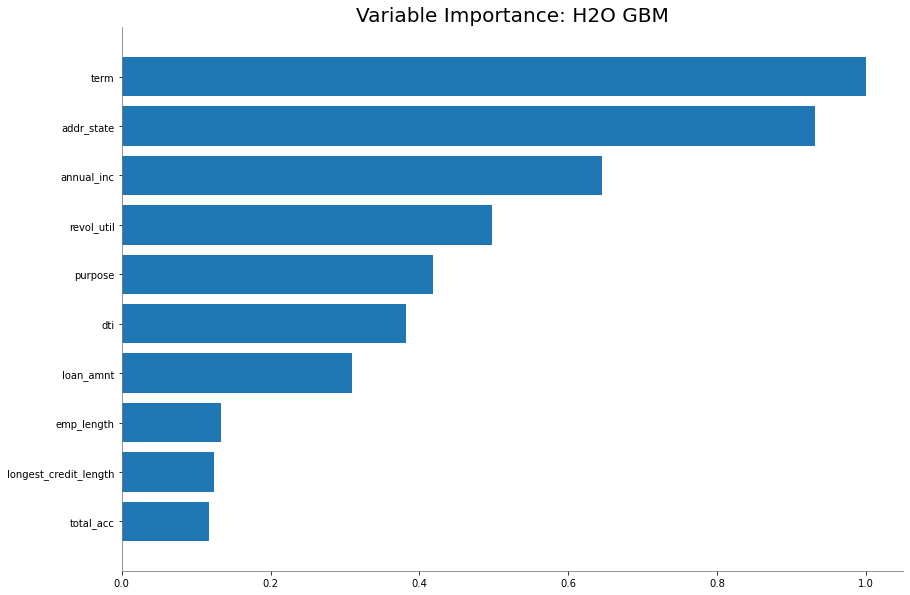

```python
import matplotlib.pyplot as plt
%matplotlib inline

select_model.varimp_plot()
```

# Step 4 (of 7). Feature Engineering to Improve Model Performance

The goal of this section is to improve upon these predictors through a number of feature engineering steps. In particular, we will perform four feature engineering tasks on select variables:

**Creating Target Encoding**

- Loan Purpose
- State of Residence

**Separating Typical from Extreme**

- Loan Amount
- Annual Income
- Debt to Income Ratio
- Number of Delinquencies in the Past 2 Years
- Revolving Credit Line Utilized
- Number of Credit Lines
- Longest Credit Length

**Creating Indicator Functions**

- Term
- Income Verification Status
- Employment Length (Missing Value)

**Combining Categories**

- Home Ownership

## 1. Creating Target Encodings

### 1.1. Introduction

Some of the engineered features we try below use [cross-validated mean target encoding](https://github.com/h2oai/h2o-tutorials/blob/master/best-practices/categorical-predictors/target_encoding.md) of categorical predictors. This is especially useful in high-cardinality categorical variables, such as state, where one-hot encodings will tend to overfit infrequent categories.

Target encodings replace categorical levels with a numeric value representing some function of the target (or $y$) variable, such as the mean. The figure below shows a typical mean target encoding.

[figure not shown]

However, because we are using a function of the result as an input to predict the result, this can easily lead to data leakage and inaccurate (usually overly-optimistic) models. Cross validation attempts to correct for this by calculating the value for each row based on other folds.

We will use the [H2O-3 Target Encoding Estimator](http://docs.h2o.ai/h2o/latest-stable/h2o-docs/data-munging/target-encoding.html) to replace categorical values with a mean of the target variable. By setting the `data_leakage_handling` parameter to `k-fold`, H2O will return an appropriately cross-validated encoding. We will also introduce `blending`, which corrects for categories with small group sizes.

#### Loan Purpose

Inspect a table of `purpose` levels, sorted from most frequent to least:

```python
import numpy as np

tbl = train["purpose"].table().as_data_frame()
tbl["Percent"] = np.round((100 * tbl["Count"]/train.nrows), 2)
tbl = tbl.sort_values(by = "Count", ascending = 0)
tbl = tbl.reset_index(drop = True)
print(tbl)
```

```
               purpose  Count  Percent
0   debt_consolidation  74613    56.82
1          credit_card  24642    18.77
2                other   8433     6.42
3     home_improvement   7866     5.99
4       major_purchase   3788     2.88
5       small_business   3107     2.37
6                  car   2274     1.73
7              medical   1644     1.25
8              wedding   1412     1.08
9               moving   1160     0.88
10               house   1009     0.77
11            vacation    882     0.67
12         educational    327     0.25
13    renewable_energy    153     0.12
```

Given that there is a high concentration of loans for debt consolidation (56.87%), a sizable number for credit card (18.78%), and the remaining 24.35% loans are spread amongst 12 other purposes, we will use mean target encoding to avoid overfitting the latter group. In addition, we use blending to better estimate categories levels with smaller counts.

#### State

Create a table for *state of residence* like we did for *loan purpose*.

```python
tbl = train["addr_state"].table().as_data_frame()
tbl["Percent"] = np.round((100 * tbl["Count"]/train.nrows), 2)
tbl = tbl.sort_values(by = "Count", ascending = 0)
tbl = tbl.reset_index(drop = True)
print(tbl)
```

```
   addr_state  Count  Percent
0          CA  22929    17.46
1          NY  11422     8.70
2          TX   9797     7.46
3          FL   9140     6.96
4          NJ   5077     3.87
5          IL   4872     3.71
6          PA   4334     3.30
7          VA   4237     3.23
8          GA   4216     3.21
9          OH   3900     2.97
10         NC   3479     2.65
11         MA   3344     2.55
12         AZ   3196     2.43
13         MD   3123     2.38
```

[output cut: 36 more lines]

High-cardinality categorical variables, such as `addr_state`, are also prime candidates for target encoding. In addition to the high-cardinality, the top 4 levels of `addr_state` account for 40% of the data, thus blending will be important in this case as well.

### 1.2. Target Encoding using H2O

Start by importing the Target Encoding Estimator

```python
from h2o.estimators import H2OTargetEncoderEstimator

response = "bad_loan"
predictors = train.col_names
predictors.remove(response)
predictors.remove("int_rate")

transformed = predictors.copy()
```

and specify the columns to encode

```python
encoded_columns = ["purpose", "addr_state"]
```

Note that we will be using the same parameter values to create the mean target encoding for each of these variables. One could also encode each variable separately with different parameters, if the the analysis or data require it.

#### Blending

The `blending` parameter determines whether the target average will be weighted based on the group count. Some groups may have a small number of records making the target average unreliable. Using a blended average consisting of a weighted average of the group's target value and the global target value can help prevent this.

When `blending=True`, a value for smoothing can be provided. The default value is 20.

When `blending=True`, a value for [inflection point](http://docs.h2o.ai/h2o/latest-stable/h2o-docs/data-munging/target-encoding.html#inflection_point) can be provided. This determines half of the minimal sample size for which we completely trust the estimate based on the sample size of the categorical level. The default value is 10.

In order to prevent overfitting, one can also add random noise to the target average. The `noise-level` parameter can be used to specify the amount of [noise](http://docs.h2o.ai/h2o/latest-stable/h2o-docs/data-munging/target-encoding.html#noise-level).

#### Data Leakage

We will use the `data_leakage_handling` parameter to control data leakage by setting it to the **k_fold** strategy. For more information on other data leakage strategies read [here](http://docs.h2o.ai/h2o/latest-stable/h2o-docs/data-munging/target-encoding.html#data-leakage-handling).

```python
# For k_fold strategy we need to provide fold column
fold_column = "kfold_column"

train[fold_column] = train.kfold_column(n_folds=5, seed=1234)
```

```python
# Train a TE model
lend_te = H2OTargetEncoderEstimator(fold_column=fold_column,
                                    inflection_point=5,
                                    smoothing=10,
                                    noise=0.10,
                                    data_leakage_handling="k_fold",
                                    blending=True)

lend_te.train(x=encoded_columns,
              y=response,
              training_frame=train)
```

```
targetencoder Model Build progress: |█████████████████████████████████████| 100%
```

```python
# New target encoded train and test sets
train_te = lend_te.transform(frame=train)
test_te = lend_te.transform(frame=test, noise=0.0)
```

```python
response = "bad_loan"
predictors = train_te.col_names
predictors.remove(response)
predictors.remove("int_rate")
predictors.remove("kfold_column")
transformed = predictors.copy()
```

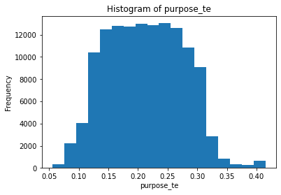

```python
transformed.remove("purpose")
train_te["purpose_te"].hist()
```

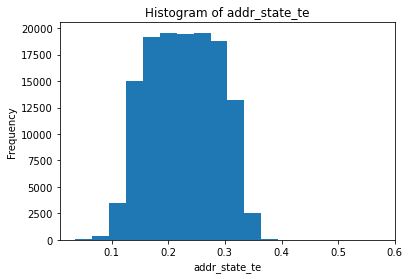

```python
transformed.remove("addr_state")
train_te["addr_state_te"].hist()
```

```python
train = train_te
test = test_te
```

## 2. Separating Typical from Extreme

A powerful approach to engineer new features, especially in the case of high noise or variables with extreme values, is to create two or more features out of one. The main goal of this exercise is to understand the underlying structure of a variable with respect to the response, creating a core function ("typical") and then deviations from that function.

We use the following convenience functions for investigating variables below

```python
def logit(p):
    return np.log(p) - np.log(1 - p)

def mean_target(data, x, y = "bad_loan"):
    grouped_data = data[[x, y]].group_by([x])
    stats = grouped_data.count(na = "ignore").mean(na = "ignore")
    return stats.get_frame().as_data_frame()
```

### 2.1. Separating Typical from Extreme Loan Amount

After binning `loan_amt` using H2OFrame's [`cut`](http://docs.h2o.ai/h2o/latest-stable/h2o-py/docs/frame.html?highlight=cut#h2o.frame.H2OFrame.cut) function and looking at the fraction of bad loans on a logit scale, we see that the chance of a bad loan roughly increases linearly in loan amount from \$5,000 to \\$30,000 and is relatively flat below \$5,000 and above \\$30,000. To reflect this finding in the modeling, we will replace the original `loan_amnt` measure with two derived measures:

\begin{eqnarray} \text{loan_amnt_core} & = & \max(5000, \min(\text{loan_amnt}, 30000)) \\ \text{loan_amnt_diff} & = & \text{loan_amnt} - \text{loan_amnt_core} \end{eqnarray}

```python
train["loan_amnt"].quantile([0, 0.05, 0.25, 0.5, 0.75, 0.95, 1])
```

| Probs | loan_amntQuantiles |
| --- | --- |
| 0 | 500 |
| 0.05 | 3000 |
| 0.25 | 7000 |
| 0.5 | 11400 |
| 0.75 | 18000 |
| 0.95 | 30000 |
| 1 | 35000 |

```python
breaks = np.linspace(0, 35000, 8).tolist()
train["loan_amnt_cat"] = train["loan_amnt"].cut(breaks = breaks)

df = mean_target(train, "loan_amnt_cat")
df
```

|  | loan_amnt_cat | nrow | mean_bad_loan |
| --- | --- | --- | --- |
| 0 | (0.0,5000.0] | 20617 | 0.163700 |
| 1 | (5000.0,10000.0] | 40234 | 0.164711 |
| 2 | (10000.0,15000.0] | 28527 | 0.172924 |
| 3 | (15000.0,20000.0] | 19767 | 0.207720 |
| 4 | (20000.0,25000.0] | 11577 | 0.213354 |
| 5 | (25000.0,30000.0] | 5555 | 0.240324 |
| 6 | (30000.0,35000.0] | 5033 | 0.230280 |

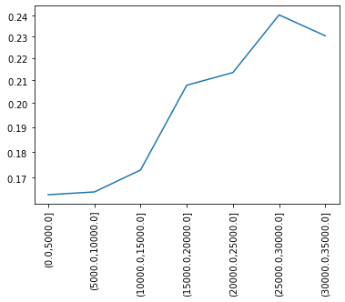

```python
plt.xticks(rotation = 90)
plt.yscale("logit")
plt.plot(df["loan_amnt_cat"], df["mean_bad_loan"])
```

```python
transformed.remove("loan_amnt")
transformed.append("loan_amnt_core")
transformed.append("loan_amnt_delta")

train["loan_amnt_core"] = h2o.H2OFrame.ifelse(train["loan_amnt"] <= 5000, 5000, train["loan_amnt"])
train["loan_amnt_core"] = h2o.H2OFrame.ifelse(train["loan_amnt_core"] <= 30000, train["loan_amnt_core"], 30000)

train["loan_amnt_delta"] = train["loan_amnt"] - train["loan_amnt_core"]
```

### 2.2. Separating Typical from Extreme Annual Income

Looking at the occurrence of bad loans on a logit scale reveal that the chance of a bad loan roughly decreases linearly in annual income from \$10,000 to \\$105,000 and is relatively flat above \$105,000. To reflect this finding in the modeling, we will replace the original `annual_inc` measure with two derived measures:

\begin{eqnarray} \text{annual_inc_core} & = & \max(10000, \min(\text{annual_inc}, 105000)) \\ \text{annual_inc_diff} & = & \text{annual_inc} - \text{annual_inc_core} \end{eqnarray}

```python
train["annual_inc"].quantile([0, 0.05, 0.25, 0.5, 0.75, 0.95, 1])
```

| Probs | annual_incQuantiles |
| --- | --- |
| 0 | 3000 |
| 0.05 | 27000 |
| 0.25 | 45000 |
| 0.5 | 61000 |
| 0.75 | 85000 |
| 0.95 | 146000 |
| 1 | 6.1e+06 |

```python
breaks = np.linspace(0, 150000, 31).tolist()
train["annual_inc_cat"] = train["annual_inc"].cut(breaks = breaks)

df = mean_target(train, "annual_inc_cat")
df.drop(df.index[:1], inplace=True) # remove NaN
df
```

|  | annual_inc_cat | nrow | mean_bad_loan |
| --- | --- | --- | --- |
| 1 | (0.0,5000.0] | 17 | 0.294118 |
| 2 | (5000.0,10000.0] | 157 | 0.216561 |
| 3 | (10000.0,15000.0] | 703 | 0.284495 |
| 4 | (15000.0,20000.0] | 1466 | 0.250341 |
| 5 | (20000.0,25000.0] | 3141 | 0.237186 |
| 6 | (25000.0,30000.0] | 5245 | 0.238704 |
| 7 | (30000.0,35000.0] | 6464 | 0.230353 |
| 8 | (35000.0,40000.0] | 9345 | 0.233387 |
| 9 | (40000.0,45000.0] | 9441 | 0.211948 |
| 10 | (45000.0,50000.0] | 10208 | 0.207190 |
| 11 | (50000.0,55000.0] | 9134 | 0.193781 |
| 12 | (55000.0,60000.0] | 9790 | 0.198264 |
| 13 | (60000.0,65000.0] | 7904 | 0.181427 |
| 14 | (65000.0,70000.0] | 7225 | 0.170657 |
| 15 | (70000.0,75000.0] | 7145 | 0.163331 |
| 16 | (75000.0,80000.0] | 6006 | 0.157010 |
| 17 | (80000.0,85000.0] | 5108 | 0.147220 |
| 18 | (85000.0,90000.0] | 4601 | 0.154097 |
| 19 | (90000.0,95000.0] | 3314 | 0.143935 |
| 20 | (95000.0,100000.0] | 4349 | 0.134974 |
| 21 | (100000.0,105000.0] | 2268 | 0.123898 |
| 22 | (105000.0,110000.0] | 2629 | 0.129707 |
| 23 | (110000.0,115000.0] | 1515 | 0.108251 |
| 24 | (115000.0,120000.0] | 2431 | 0.143974 |
| 25 | (120000.0,125000.0] | 1392 | 0.122845 |
| 26 | (125000.0,130000.0] | 1327 | 0.112283 |
| 27 | (130000.0,135000.0] | 766 | 0.124021 |
| 28 | (135000.0,140000.0] | 1016 | 0.132874 |
| 29 | (140000.0,145000.0] | 604 | 0.109272 |
| 30 | (145000.0,150000.0] | 1185 | 0.134177 |

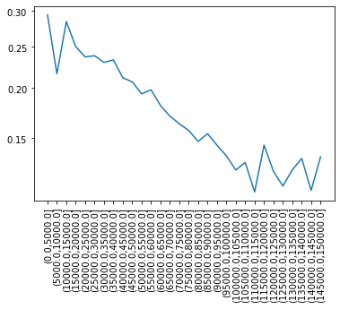

```python
plt.yscale("logit")
plt.xticks(rotation = 90)
plt.plot(df["annual_inc_cat"], df["mean_bad_loan"])
```

```python
transformed.remove("annual_inc")
transformed.append("annual_inc_core")
transformed.append("annual_inc_delta")

train["annual_inc_core"] = h2o.H2OFrame.ifelse(train["annual_inc"] <= 10000, 10000, train["annual_inc"])
train["annual_inc_core"] = h2o.H2OFrame.ifelse(train["annual_inc_core"] <= 105000,
                                               train["annual_inc_core"], 105000)

train["annual_inc_delta"] = train["annual_inc"] - train["annual_inc_core"]
```

### 2.3. Separating Typical from Extreme Debt to Income Ratio

Looking at the occurance of bad loans on a logit scale reveal that the chance of a bad loan roughly increases linearly in debt-to-income from 5% to 30% and is highly volatile outside of that range due to small numbers of observations. To reflect this finding in the modeling, we will replace the original `dti` measure with two derived measures:

\begin{eqnarray} \text{dti_core} & = & \max(5, \min(\text{dti}, 30)) \\ \text{dti_diff} & = & \text{dti} - \text{dti_core} \end{eqnarray}

```python
train["dti"].quantile([0, 0.05, 0.25, 0.5, 0.75, 0.95, 1])
```

| Probs | dtiQuantiles |
| --- | --- |
| 0 | 0 |
| 0.05 | 3.7645 |
| 0.25 | 10.21 |
| 0.5 | 15.6 |
| 0.75 | 21.26 |
| 0.95 | 29.02 |
| 1 | 39.93 |

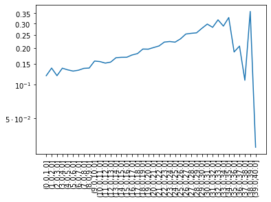

```python
breaks = np.linspace(0, 40, 41).tolist()
train["dti_cat"] = train["dti"].cut(breaks = breaks)

df = mean_target(train, "dti_cat")
df.drop(df.index[:1], inplace=True) # remove NaN

plt.yscale("logit")
plt.xticks(rotation = 90)
plt.plot(df["dti_cat"], df["mean_bad_loan"])
```

```python
df
```

|  | dti_cat | nrow | mean_bad_loan |
| --- | --- | --- | --- |
| 1 | (0.0,1.0] | 1207 | 0.119304 |
| 2 | (1.0,2.0] | 1541 | 0.138222 |
| 3 | (2.0,3.0] | 1885 | 0.119363 |
| 4 | (3.0,4.0] | 2328 | 0.137887 |
| 5 | (4.0,5.0] | 2881 | 0.133634 |
| 6 | (5.0,6.0] | 3418 | 0.130486 |
| 7 | (6.0,7.0] | 3821 | 0.132688 |
| 8 | (7.0,8.0] | 4402 | 0.137438 |
| 9 | (8.0,9.0] | 4896 | 0.138276 |
| 10 | (9.0,10.0] | 5196 | 0.157814 |
| 11 | (10.0,11.0] | 5573 | 0.156289 |
| 12 | (11.0,12.0] | 5789 | 0.151840 |
| 13 | (12.0,13.0] | 6204 | 0.154739 |
| 14 | (13.0,14.0] | 6300 | 0.167937 |
| 15 | (14.0,15.0] | 6345 | 0.169110 |
| 16 | (15.0,16.0] | 6165 | 0.169343 |
| 17 | (16.0,17.0] | 6183 | 0.176613 |
| 18 | (17.0,18.0] | 6028 | 0.180989 |
| 19 | (18.0,19.0] | 5822 | 0.196496 |
| 20 | (19.0,20.0] | 5663 | 0.196009 |
| 21 | (20.0,21.0] | 5352 | 0.201794 |
| 22 | (21.0,22.0] | 4991 | 0.207373 |
| 23 | (22.0,23.0] | 4754 | 0.221918 |
| 24 | (23.0,24.0] | 4347 | 0.224063 |
| 25 | (24.0,25.0] | 4011 | 0.221640 |
| 26 | (25.0,26.0] | 2748 | 0.234352 |
| 27 | (26.0,27.0] | 2455 | 0.254175 |
| 28 | (27.0,28.0] | 2162 | 0.257169 |
| 29 | (28.0,29.0] | 2013 | 0.259314 |
| 30 | (29.0,30.0] | 1860 | 0.279032 |
| 31 | (30.0,31.0] | 1194 | 0.298157 |
| 32 | (31.0,32.0] | 1048 | 0.283397 |
| 33 | (32.0,33.0] | 836 | 0.318182 |
| 34 | (33.0,34.0] | 820 | 0.289024 |
| 35 | (34.0,35.0] | 595 | 0.329412 |
| 36 | (35.0,36.0] | 59 | 0.186441 |
| 37 | (36.0,37.0] | 58 | 0.206897 |
| 38 | (37.0,38.0] | 55 | 0.109091 |
| 39 | (38.0,39.0] | 50 | 0.360000 |
| 40 | (39.0,40.0] | 37 | 0.027027 |

```python
transformed.remove("dti")
transformed.append("dti_core")
transformed.append("dti_delta")

train["dti_core"] = h2o.H2OFrame.ifelse(train["dti"] <= 5, 5, train["dti"])
train["dti_core"] = h2o.H2OFrame.ifelse(train["dti_core"] <= 30, train["dti_core"], 30)

train["dti_delta"] = train["dti"] - train["dti_core"]
```

### 2.4. Separating Typical from Extreme Number of Delinquencies in the Past 2 Years

The chance of a bad loan seems to max out at 3 delinquent payments in the past two years. To reflect this finding in the modeling, we will replace the original `delinq_2yrs` measure with two derived measures:

\begin{eqnarray} \text{delinq_2yrs_core} & = & \min(\text{delinq_2yrs}, 3) \\ \text{delinq_2yrs_diff} & = & \text{delinq_2yrs} - \text{delinq_2yrs_core} \end{eqnarray}

```python
train["delinq_2yrs"].quantile([0, 0.05, 0.25, 0.5, 0.75, 0.95, 1])
```

| Probs | delinq_2yrsQuantiles |
| --- | --- |
| 0 | 0 |
| 0.05 | 0 |
| 0.25 | 0 |
| 0.5 | 0 |
| 0.75 | 0 |
| 0.95 | 1 |
| 1 | 18 |

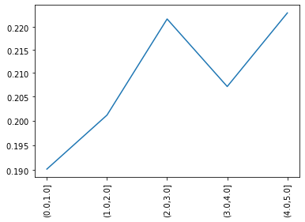

```python
breaks = np.linspace(0, 5, 6).tolist()
train["delinq_2yrs_cat"] = train["delinq_2yrs"].cut(breaks = breaks)

df = mean_target(train, "delinq_2yrs_cat")
df.drop(df.index[:1], inplace=True) # remove NaN

plt.yscale("logit")
plt.xticks(rotation = 90)
plt.plot(df["delinq_2yrs_cat"], df["mean_bad_loan"])
```

```python
df
```

|  | delinq_2yrs_cat | nrow | mean_bad_loan |
| --- | --- | --- | --- |
| 1 | (0.0,1.0] | 13744 | 0.190192 |
| 2 | (1.0,2.0] | 3714 | 0.201131 |
| 3 | (2.0,3.0] | 1204 | 0.221761 |
| 4 | (3.0,4.0] | 478 | 0.207113 |
| 5 | (4.0,5.0] | 251 | 0.223108 |

```python
transformed.remove("delinq_2yrs")
transformed.append("delinq_2yrs_core")
transformed.append("delinq_2yrs_delta")

train["delinq_2yrs_core"] = h2o.H2OFrame.ifelse(train["delinq_2yrs"] <= 3, train["delinq_2yrs"], 3)
train["delinq_2yrs_delta"] = train["delinq_2yrs"] - train["delinq_2yrs_core"]
```

### 2.5. Separating Typical from Extreme Revolving Credit Line Utilized

The relationship between credit line utilized is somewhat interesting. There appears to be a higher rate for a bad loan when 0% of the credit lines are utilized, then it drops down slightly and roughly increases linearly in credit line utilized up to 100%. To reflect this finding in the modeling, we will replace the original `revol_util` measure with three derived measures:

```python
train["revol_util"].quantile([0, 0.05, 0.25, 0.5, 0.75, 0.95, 1])
```

| Probs | revol_utilQuantiles |
| --- | --- |
| 0 | 0 |
| 0.05 | 8.7 |
| 0.25 | 35.5 |
| 0.5 | 55.9 |
| 0.75 | 74.3 |
| 0.95 | 92.4 |
| 1 | 150.7 |

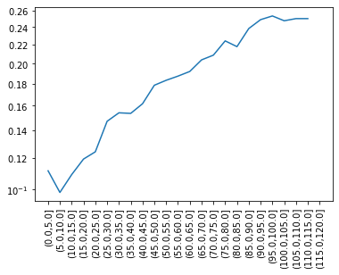

```python
breaks = np.linspace(0, 120, 25).tolist()
train["revol_util_cat"] = train["revol_util"].cut(breaks = breaks)

df = mean_target(train, "revol_util_cat")
df.drop(df.index[:1], inplace=True) # remove NaN

plt.yscale("logit")
plt.xticks(rotation = 90)
plt.plot(df["revol_util_cat"], df["mean_bad_loan"])
```

```python
df
```

|  | revol_util_cat | nrow | mean_bad_loan |
| --- | --- | --- | --- |
| 1 | (0.0,5.0] | 2999 | 0.111370 |
| 2 | (5.0,10.0] | 3285 | 0.098326 |
| 3 | (10.0,15.0] | 3523 | 0.108998 |
| 4 | (15.0,20.0] | 4141 | 0.119053 |
| 5 | (20.0,25.0] | 4910 | 0.124033 |
| 6 | (25.0,30.0] | 5647 | 0.146981 |
| 7 | (30.0,35.0] | 6386 | 0.153930 |
| 8 | (35.0,40.0] | 7142 | 0.153458 |
| 9 | (40.0,45.0] | 7688 | 0.161681 |
| 10 | (45.0,50.0] | 8423 | 0.178440 |
| 11 | (50.0,55.0] | 8670 | 0.183160 |
| 12 | (55.0,60.0] | 8814 | 0.187202 |
| 13 | (60.0,65.0] | 9166 | 0.191796 |
| 14 | (65.0,70.0] | 9076 | 0.203614 |
| 15 | (70.0,75.0] | 8491 | 0.208574 |
| 16 | (75.0,80.0] | 8192 | 0.224121 |
| 17 | (80.0,85.0] | 7554 | 0.217765 |
| 18 | (85.0,90.0] | 6527 | 0.238241 |
| 19 | (90.0,95.0] | 5596 | 0.248749 |
| 20 | (95.0,100.0] | 3424 | 0.253213 |
| 21 | (100.0,105.0] | 194 | 0.247423 |
| 22 | (105.0,110.0] | 28 | 0.250000 |
| 23 | (110.0,115.0] | 8 | 0.250000 |
| 24 | (115.0,120.0] | 3 | 0.000000 |

```python
transformed.remove("revol_util")
transformed.append("revol_util_0")
transformed.append("revol_util_core")
transformed.append("revol_util_delta")

train["revol_util_0"] = train["revol_util"] == 0
train["revol_util_core"] = h2o.H2OFrame.ifelse(train["revol_util"] <= 100, train["revol_util"], 100)
train["revol_util_delta"] = train["revol_util"] - train["revol_util_core"]
```

### 2.6. Separating Typical from Extreme Number of Credit Lines

Looking at the occurance of bad loans on a logit scale reveal that the chance of a bad loan roughly decreases linearly in number of lines of credit up to about 50. To reflect this finding in the modeling, we will replace the original `total_acc` measure with two derived measures:

\begin{eqnarray} \text{total_acc_core} & = & \min(\text{total_acc}, 50) \\ \text{total_acc_diff} & = & \text{total_acc} - \text{total_acc_core} \end{eqnarray}

```python
train["total_acc"].quantile([0, 0.05, 0.25, 0.5, 0.75, 0.95, 1])
```

| Probs | total_accQuantiles |
| --- | --- |
| 0 | 1 |
| 0.05 | 8 |
| 0.25 | 16 |
| 0.5 | 23 |
| 0.75 | 31 |
| 0.95 | 46 |
| 1 | 102 |

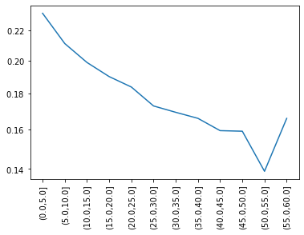

```python
breaks = np.linspace(0, 60, 13).tolist()
train["total_acc_cat"] = train["total_acc"].cut(breaks = breaks)

df = mean_target(train, "total_acc_cat")
df.drop(df.index[:1], inplace=True) # remove NaN

plt.yscale("logit")
plt.xticks(rotation = 90)
plt.plot(df["total_acc_cat"], df["mean_bad_loan"])
```

```python
df
```

|  | total_acc_cat | nrow | mean_bad_loan |
| --- | --- | --- | --- |
| 1 | (0.0,5.0] | 1852 | 0.231641 |
| 2 | (5.0,10.0] | 10208 | 0.211011 |
| 3 | (10.0,15.0] | 18877 | 0.198813 |
| 4 | (15.0,20.0] | 23094 | 0.190049 |
| 5 | (20.0,25.0] | 22751 | 0.183772 |
| 6 | (25.0,30.0] | 18733 | 0.172797 |
| 7 | (30.0,35.0] | 13804 | 0.169226 |
| 8 | (35.0,40.0] | 9030 | 0.165891 |
| 9 | (40.0,45.0] | 5670 | 0.159259 |
| 10 | (45.0,50.0] | 3353 | 0.158962 |
| 11 | (50.0,55.0] | 1865 | 0.138874 |
| 12 | (55.0,60.0] | 1037 | 0.165863 |

```python
(train["total_acc"] == None).table()
```

| C1 | Count |
| --- | --- |
| 0 | 131287 |
| 1 | 23 |

```python
transformed.remove("total_acc")
transformed.append("total_acc_core")
transformed.append("total_acc_delta")

train["total_acc_core"] = h2o.H2OFrame.ifelse(train["total_acc"] <= 50, train["total_acc"], 50)
train["total_acc_delta"] = train["total_acc"] - train["total_acc_core"]
```

### 2.7. Separating Typical from Extreme Longest Credit Length

Looking at the occurance of bad loans on a logit scale reveal that the chance of a bad loan roughly decreases linearly in longest credit length from 3 to 20 years and is highly volatile outside of that range due to small numbers of observations. To reflect this finding in the modeling, we will replace the original `longest_credit_length` measure with two derived measures:

\begin{eqnarray} \text{longest_credit_length_core} & = & \max(3, \min(\text{longest_credit_length}, 20)) \\ \text{longest_credit_length_diff} & = & \text{longest_credit_length} - \text{longest_credit_length_core} \end{eqnarray}

```python
train["longest_credit_length"].quantile([0, 0.05, 0.25, 0.5, 0.75, 0.95, 1])
```

| Probs | longest_credit_lengthQuantiles |
| --- | --- |
| 0 | 0 |
| 0.05 | 6 |
| 0.25 | 10 |
| 0.5 | 14 |
| 0.75 | 18 |
| 0.95 | 28 |
| 1 | 65 |

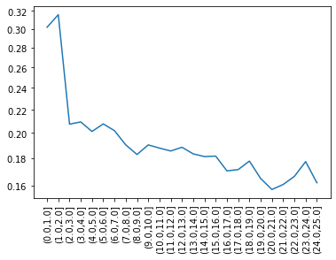

```python
breaks = np.linspace(0, 25, 26).tolist()
train["longest_credit_length_cat"] = train["longest_credit_length"].cut(breaks = breaks)

df = mean_target(train, "longest_credit_length_cat")
df.drop(df.index[:1], inplace=True) # remove NaN

plt.yscale("logit")
plt.xticks(rotation = 90)
plt.plot(df["longest_credit_length_cat"], df["mean_bad_loan"])
```

```python
df
```

|  | longest_credit_length_cat | nrow | mean_bad_loan |
| --- | --- | --- | --- |
| 1 | (0.0,1.0] | 53 | 0.301887 |
| 2 | (1.0,2.0] | 76 | 0.315789 |
| 3 | (2.0,3.0] | 747 | 0.207497 |
| 4 | (3.0,4.0] | 1992 | 0.209337 |
| 5 | (4.0,5.0] | 3199 | 0.201313 |
| 6 | (5.0,6.0] | 4300 | 0.207674 |
| 7 | (6.0,7.0] | 5115 | 0.201955 |
| 8 | (7.0,8.0] | 5626 | 0.190366 |
| 9 | (8.0,9.0] | 6127 | 0.182797 |
| 10 | (9.0,10.0] | 7807 | 0.190342 |
| 11 | (10.0,11.0] | 9488 | 0.187816 |
| 12 | (11.0,12.0] | 10252 | 0.185525 |
| 13 | (12.0,13.0] | 10049 | 0.188476 |
| 14 | (13.0,14.0] | 8964 | 0.183289 |
| 15 | (14.0,15.0] | 7798 | 0.181200 |
| 16 | (15.0,16.0] | 6835 | 0.181565 |
| 17 | (16.0,17.0] | 6183 | 0.170467 |
| 18 | (17.0,18.0] | 5280 | 0.171402 |
| 19 | (18.0,19.0] | 4720 | 0.177754 |
| 20 | (19.0,20.0] | 3747 | 0.164932 |
| 21 | (20.0,21.0] | 3148 | 0.157243 |
| 22 | (21.0,22.0] | 2663 | 0.160721 |
| 23 | (22.0,23.0] | 2439 | 0.166462 |
| 24 | (23.0,24.0] | 2289 | 0.177370 |
| 25 | (24.0,25.0] | 1970 | 0.161929 |

```python
transformed.remove("longest_credit_length")
transformed.append("longest_credit_length_core")
transformed.append("longest_credit_length_delta")

train["longest_credit_length_core"] = h2o.H2OFrame.ifelse(train["longest_credit_length"] <= 3,
                                                          3, train["longest_credit_length"])
train["longest_credit_length_core"] = h2o.H2OFrame.ifelse(train["longest_credit_length_core"] <= 20,
                                                          train["longest_credit_length_core"], 20)
train["longest_credit_length_delta"] = train["longest_credit_length"] - train["longest_credit_length_core"]
```

## 3. Create Indicator Functions

### 3.1. Converting Term to a 0/1 Indicator

```python
train["term"].table()
```

| term | Count |
| --- | --- |
| 36 months | 104009 |
| 60 months | 27301 |

```python
transformed.remove("term")
transformed.append("term_60months")

train["term_60months"] = train["term"] == "60 months"

train["term_60months"].table()
```

| term_60months | Count |
| --- | --- |
| 0 | 104009 |
| 1 | 27301 |

### 3.2. Converting Income Verification Status to a 0/1 Indicator

Given that incomes are either verified or not verified, we will create a simplifed `verified` binary indicator that is 1 when income has been verified.

```python
train["verification_status"].table()
```

| verification_status | Count |
| --- | --- |
| not verified | 47173 |
| verified | 84137 |

```python
transformed.remove("verification_status")
transformed.append("verified")

train["verified"] = train["verification_status"] == "verified"
train["verified"].table()
```

| verified | Count |
| --- | --- |
| 0 | 47173 |
| 1 | 84137 |

### 3.3. Creating Missing Value Indicator for Employment Length

The most interesting characteristic about employment length is whether or not it is missing. The divide between those with missing values for employment length to those who have a recorded employment length is 26.3% bad loans to 18.0% bad loans respectively. Interestingly, there doesn't appear to be any differences in bad loans across employment lengths.

```python
train["emp_length"].summary()
```

|  | emp_length |
| --- | --- |
| type | int |
| mins | 0.0 |
| mean | 5.678111384731959 |
| maxs | 10.0 |
| sigma | 3.611367159033747 |
| zeros | 11488 |
| missing | 4614 |
| 0 | 10.0 |
| 1 | 0.0 |
| 2 | 10.0 |
| 3 | 3.0 |
| 4 | 9.0 |
| 5 | 4.0 |
| 6 | 0.0 |
| 7 | 5.0 |
| 8 | 0.0 |
| 9 | 3.0 |

```python
transformed.append("emp_length_missing")
train["emp_length_missing"] = train["emp_length"] == None
train["emp_length_missing"].table()
```

| emp_length_missing | Count |
| --- | --- |
| 0 | 126696 |
| 1 | 4614 |

## 4. Combining Categories

### 4.1. Combining Categories in Home Ownership

Although there are 6 recorded categories within home ownership, only three had over 200 observations: OWN, MORTGAGE, and RENT. The remaining three are so infrequent we will combine them {ANY, NONE, OTHER} with RENT to form an enlarged OTHER category. This new `home_ownership_3cat` variable will have values in {MORTGAGE, OTHER, OWN}.

```python
mean_target(train, "home_ownership")
```

|  | home_ownership | nrow | mean_bad_loan |
| --- | --- | --- | --- |
| 0 | MORTGAGE | 63915 | 0.162810 |
| 1 | NONE | 28 | 0.250000 |
| 2 | OTHER | 124 | 0.225806 |
| 3 | OWN | 10805 | 0.188801 |
| 4 | RENT | 56438 | 0.204189 |

```python
lvls = ["OTHER", "MORTGAGE", "OTHER", "OTHER", "OWN", "OTHER"]
train["home_ownership_3cat"] = train["home_ownership"].set_levels(lvls).ascharacter().asfactor()
train[["home_ownership", "home_ownership_3cat"]].table()
```

| home_ownership | home_ownership_3cat | Counts |
| --- | --- | --- |
| MORTGAGE | MORTGAGE | 63915 |
| NONE | OTHER | 28 |
| OTHER | OTHER | 124 |
| OWN | OWN | 10805 |
| RENT | OTHER | 56438 |

```python
mean_target(train, "home_ownership_3cat")
```

|  | home_ownership_3cat | nrow | mean_bad_loan |
| --- | --- | --- | --- |
| 0 | MORTGAGE | 63915 | 0.162810 |
| 1 | OTHER | 56590 | 0.204259 |
| 2 | OWN | 10805 | 0.188801 |

```python
transformed.remove("home_ownership")
transformed.append("home_ownership_3cat")
```

# Step 5 (of 7). Train Models using Transformed Data

The complete variable set, including transformed variables, are

```python
transformed
```

```
['emp_length',
 'purpose_te',
 'addr_state_te',
 'loan_amnt_core',
 'loan_amnt_delta',
 'annual_inc_core',
 'annual_inc_delta',
 'dti_core',
 'dti_delta',
 'delinq_2yrs_core',
 'delinq_2yrs_delta',
 'revol_util_0',
 'revol_util_core',
 'revol_util_delta',
 'total_acc_core',
 'total_acc_delta',
 'longest_credit_length_core',
 'longest_credit_length_delta',
 'term_60months',
 'verified',
 'emp_length_missing',
 'home_ownership_3cat']
```

We now fit a new set of models using AutoML

```python
aml_trans = H2OAutoML(max_models = 6, exclude_algos = ['GLM', 'DeepLearning'])
aml_trans.train(x = transformed, y = response, training_frame = train)
```

```
AutoML progress: |████████████████████████████████████████████████████████| 100%
```

```python
print(aml_trans.leaderboard)
```

| model_id | auc | logloss | aucpr | mean_per_class_error | rmse | mse |
| --- | --- | --- | --- | --- | --- | --- |
| StackedEnsemble_AllModels_AutoML_20201021_190618 | 0.678803 | 0.446949 | 0.317394 | 0.370776 | 0.374803 | 0.140477 |
| StackedEnsemble_BestOfFamily_AutoML_20201021_190618 | 0.678389 | 0.447089 | 0.316676 | 0.370053 | 0.374867 | 0.140525 |
| GBM_1_AutoML_20201021_190618 | 0.677004 | 0.445794 | 0.314848 | 0.372164 | 0.374449 | 0.140212 |
| GBM_2_AutoML_20201021_190618 | 0.675558 | 0.446262 | 0.313652 | 0.372983 | 0.374657 | 0.140368 |
| XGBoost_3_AutoML_20201021_190618 | 0.675422 | 0.446388 | 0.312896 | 0.372889 | 0.374757 | 0.140443 |
| DRF_1_AutoML_20201021_190618 | 0.658229 | 0.453904 | 0.294227 | 0.385206 | 0.377875 | 0.14279 |
| XGBoost_1_AutoML_20201021_190618 | 0.650992 | 0.460662 | 0.288432 | 0.390532 | 0.38079 | 0.145001 |
| XGBoost_2_AutoML_20201021_190618 | 0.632408 | 0.476886 | 0.271245 | 0.406729 | 0.386823 | 0.149632 |

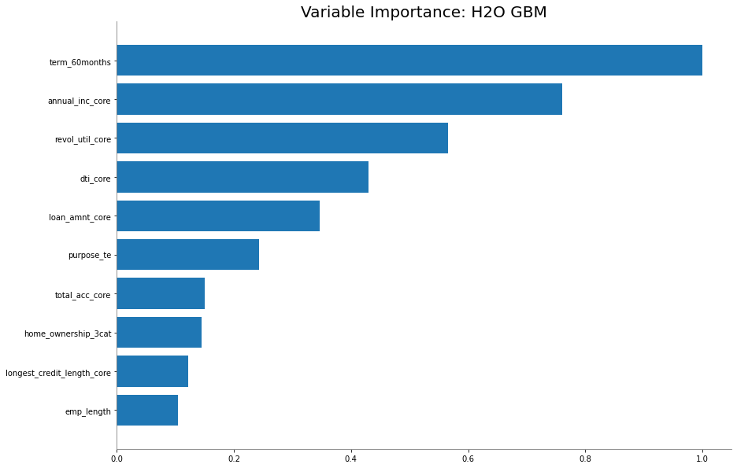

```python
best_model_trans = h2o.get_model(aml_trans.leaderboard[2,'model_id'])
best_model_trans.varimp_plot()
```

```python
print("AUC     (transformed): train = {:.4f}, xval = {:.4f}" \
      .format(best_model_trans.auc(train = True),
              best_model_trans.auc(xval = True)))
print("Logloss (transformed): train = {:.4f}, xval = {:.4f}" \
      .format(best_model_trans.logloss(train = True),
              best_model_trans.logloss(xval = True)))
```

```
AUC     (transformed): train = 0.7062, xval = 0.6770
Logloss (transformed): train = 0.4338, xval = 0.4458
```

# Step 6 (of 7). Assignment: Transform Test Data (Optional)

In order to use the `model_performance` command to evaluate the model on the holdout training data set, you will need to transform the training data using the same feature engineering transformations created above. In other words, transform the data from

```python
response = "bad_loan"
transformed_test = test.col_names
transformed_test.remove(response)
transformed_test.remove("int_rate")
transformed_test
```

```
['loan_amnt',
 'emp_length',
 'annual_inc',
 'dti',
 'delinq_2yrs',
 'revol_util',
 'total_acc',
 'longest_credit_length',
 'purpose_te',
 'addr_state_te',
 'term',
 'home_ownership',
 'purpose',
 'addr_state',
 'verification_status']
```

to the variables below

```python
transformed
```

```
['emp_length',
 'purpose_te',
 'addr_state_te',
 'loan_amnt_core',
 'loan_amnt_delta',
 'annual_inc_core',
 'annual_inc_delta',
 'dti_core',
 'dti_delta',
 'delinq_2yrs_core',
 'delinq_2yrs_delta',
 'revol_util_0',
 'revol_util_core',
 'revol_util_delta',
 'total_acc_core',
 'total_acc_delta',
 'longest_credit_length_core',
 'longest_credit_length_delta',
 'term_60months',
 'verified',
 'emp_length_missing',
 'home_ownership_3cat']
```

# Step 7 (of 7). Shutdown Sparkling Water Cluster

```python
h2o.cluster().shutdown()
```

```
H2O session _sid_8567 closed.
```

Once your work is completed, shutting down the Sparkling Water cluster frees up the resources reserved by H2O.